# Predicting Apple Inc. (AAPL) Stock Prices with Artificial Neural Networks

## 👋 Introduction

[figure not shown]

Stock price prediction is a crucial topic in financial markets, attracting interest from traders, investors, and data scientists. Traditional forecasting models rely on statistical techniques, but with the rise of Artificial Intelligence (AI), machine learning models, particularly Artificial Neural Networks (ANNs), have become a powerful tool for time-series prediction. In this notebook, we will use ANNs to predict the stock price of Apple Inc. (AAPL) based on historical stock market data. By the end of this notebook, we aim to gain insights into the potential and limitations of ANN-based stock price prediction.

- 📖 Domain Understanding
  - Background
  - Research
- 📦 Data Provisioning
  - 📋 Data Requirements
  - 🗂️ Data Collection
  - 📊 Data Understanding
  - 🛠️ Data Preparation
- 🔮 Predictions
  - Modeling Plan
  - Train-test split
  - 🔷 Basic Feedforward ANN (MLP)
    - 🧹 Preprocessing
    - 🧬 Modelling
    - 🧐 Evaluation
  - 🔷 Deep Feedforward ANN
    - 🧬 Modelling
    - 🧐 Evaluation
    - Hyperparameter Tuning for Feedforward ANN
  - 🔷 LSTM (Recurrent Neural Network)
    - 🧹 Preprocessing
    - 🧬 Modelling
    - 🧐 Evaluation
    - Hyperparameter Tuning for LSTM
  - 🔷 Bidirectional LSTM
    - 🧬 Modelling
    - 🧐 Evaluation
  - Comparison
- 🤝 Conclusion
- 📚 References

## 📖 Domain Understanding

Stock price prediction is a key area in financial analytics and trading, where machine learning models are used to predict future stock prices based on historical market data. Investors, traders, and financial institutions rely on these predictions to make informed decisions about buying, selling, or holding assets. The goal of this notebook is to leverage Artificial Neural Networks (ANNs) to analyze historical stock prices and predict future trends.

According to the Efficient Market Hypothesis (EMH), stock prices fully reflect all available information, making short-term predictions challenging. However, advances in machine learning and deep learning have enabled traders to uncover hidden patterns that traditional statistical methods may not detect.

Why is Stock Price Prediction Important?

- Informed Decision-Making: Assists traders and investors in making data-driven investment choices.
- Risk Management: Enables financial analysts to assess market risks and mitigate potential losses.

Challenges in Stock Price Prediction:

- Market Volatility: Prices fluctuate due to unpredictable economic events, news, and investor sentiment.
- External Influences: Factors such as macroeconomic trends, interest rates, company earnings, and geopolitical events impact stock movements. Despite these challenges, integrating AI into investment strategies has shown promise. A recent survey by Mercer (2024) highlighted that over 90% of investment managers are either using or planning to use AI, with 54% already integrating it. AI's capabilities range from stock analysis and sentiment summarization to portfolio management and predictive modeling, enhancing decision-making and potentially improving investment outcomes.

```python
import pandas as pd
import matplotlib.pyplot as plt
import seaborn as sns
import numpy as np
import yfinance as yf

from sklearn.preprocessing import MinMaxScaler
import tensorflow as tf
from tensorflow import keras
from tensorflow.keras import layers
from tensorflow.keras.optimizers import Adam
from tensorflow.keras.layers import Bidirectional
import keras_tuner as kt
```

## 📦 Data Provisioning

This section covers the fundamental aspects of data provisioning. For this notebook, it was decided to follow the AI Project Methodology to maintain a structured approach. The key steps in this section are: Data Requirements, Data Collection, Data Understanding, and Data Preparation.

### 📋 Data Requirements

#### Data Elements

##### Numerical Data

- Data Type: Numerical
- Example: Stock prices (Open, High, Low, Close), trading volume
- Units: U.S. Dollars (USD) for prices, shares for volume
- Range: Varies based on market trends

##### Time-Series Data

- Data Type: Sequential/Numerical
- Example: Daily stock prices
- Derivation: Time-indexed stock prices over a historical period
- Size: Each row represents a trading day
- Content: Closing prices, moving averages, volume

#### Data Volume

For effective training, a sufficient historical dataset is required. In this project, we will use Apple Inc. (AAPL) stock data from Yahoo Finance, spanning over 40 years to ensure a diverse dataset.

#### Data Quality Standards

The dataset must adhere to the following standards:

- Accuracy – Correct stock price values
- Completeness – No missing values in critical fields
- Consistency – Data should be uniform across time periods
- Validation – We will check for outliers, missing values, and anomalies

#### Data Dictionary

| Data Element | Data Type | Units | Description |
| --- | --- | --- | --- |
| **Open Price** | Numerical | USD | Opening stock price for the day |
| **High Price** | Numerical | USD | Highest price of the day |
| **Low Price** | Numerical | USD | Lowest price of the day |
| **Close Price** | Numerical | USD | Closing stock price for the day |
| **Volume** | Numerical | Shares | Number of shares traded |
| **Date** | Time-Series | YYYY-MM-DD | Date of the stock market data |

### 🗂️ Data Collection

#### Data Source

For this project, we use Yahoo Finance as the primary data source. Yahoo Finance provides historical stock market data, real-time price updates, financial reports, and other key market insights. It is widely used in financial analysis and is an excellent source for machine learning projects.

#### Collecting the Data

We have already insyalled and imported the yfinance library in the above section with all imports. We fetch the maximum available stock price history for Apple Inc. (AAPL):

```python
# stock symbol
stock_symbol = "AAPL"

# fetch historical data (maximum available)
aapl_data = yf.download(stock_symbol, period="max")
```

```
[*********************100%***********************]  1 of 1 completed
```

Then we review the data by printing the first few rows to ensure the proper retrieval.

```python
print(aapl_data.head())
```

```
Price          Close      High       Low      Open     Volume
Ticker          AAPL      AAPL      AAPL      AAPL       AAPL
Date
1980-12-12  0.098726  0.099155  0.098726  0.098726  469033600
1980-12-15  0.093575  0.094005  0.093575  0.094005  175884800
1980-12-16  0.086707  0.087136  0.086707  0.087136  105728000
1980-12-17  0.088853  0.089282  0.088853  0.088853   86441600
1980-12-18  0.091429  0.091858  0.091429  0.091429   73449600
```

#### Data Storage

The downloaded data can be saved locally as a CSV file. This ensures easy access and allows us to reload the dataset without making repeated API calls.

```python
aapl_data.to_csv("AAPL_stock_data.csv", index=True)
```

#### Sample the Data

```python
print("📌 Data Overview:")
print(f"Start Date: {aapl_data.index[0]}")
print(f"End Date: {aapl_data.index[-1]}")
print(f"Number of Entries: {len(aapl_data)}")

print("\n📃 Sample Data:")
print(aapl_data.tail(10))
```

```
📌 Data Overview:
Start Date: 1980-12-12 00:00:00
End Date: 2025-03-11 00:00:00
Number of Entries: 11151

📃 Sample Data:
Price            Close        High         Low        Open    Volume
Ticker            AAPL        AAPL        AAPL        AAPL      AAPL
Date
2025-02-26  240.360001  244.979996  239.130005  244.330002  44433600
2025-02-27  237.300003  242.460007  237.059998  239.410004  41153600
2025-02-28  241.839996  242.089996  230.199997  236.949997  56833400
2025-03-03  238.029999  244.029999  236.110001  241.789993  47184000
2025-03-04  235.929993  240.070007  234.679993  237.710007  53798100
2025-03-05  235.740005  236.550003  229.229996  235.419998  47227600
2025-03-06  235.330002  237.860001  233.160004  234.440002  45170400
2025-03-07  239.070007  241.369995  234.759995  235.110001  46273600
2025-03-10  227.479996  236.160004  224.220001  235.539993  72071200
2025-03-11  220.839996  225.839996  217.449997  223.809998  76087700
```

### 📊 Data Understanding

In this step, we are going to explore the data, see some trends and do as much exploration as we can. Understanding the dataset is crucial for building an effective stock price prediction model.

#### Dataset Overview

Before diving into specifics, let's inspect the dataset.

```python
print(aapl_data.head())
```

```
Price          Close      High       Low      Open     Volume
Ticker          AAPL      AAPL      AAPL      AAPL       AAPL
Date
1980-12-12  0.098726  0.099155  0.098726  0.098726  469033600
1980-12-15  0.093575  0.094005  0.093575  0.094005  175884800
1980-12-16  0.086707  0.087136  0.086707  0.087136  105728000
1980-12-17  0.088853  0.089282  0.088853  0.088853   86441600
1980-12-18  0.091429  0.091858  0.091429  0.091429   73449600
```

#### Basic Data Information

Now, we are going to check the structure and types of data.

```python
print(aapl_data.info())
print("\nMissing Values:\n", aapl_data.isnull().sum())
```

```
<class 'pandas.core.frame.DataFrame'>
DatetimeIndex: 11151 entries, 1980-12-12 to 2025-03-11
Data columns (total 5 columns):
 #   Column          Non-Null Count  Dtype
---  ------          --------------  -----
 0   (Close, AAPL)   11151 non-null  float64
 1   (High, AAPL)    11151 non-null  float64
 2   (Low, AAPL)     11151 non-null  float64
 3   (Open, AAPL)    11151 non-null  float64
 4   (Volume, AAPL)  11151 non-null  int64
dtypes: float64(4), int64(1)
memory usage: 522.7 KB
None

Missing Values:
 Price   Ticker
Close   AAPL      0
High    AAPL      0
Low     AAPL      0
Open    AAPL      0
Volume  AAPL      0
dtype: int64
```

There are 5 data columns, representing an aspect of AAPL stock price movements. These columns are:

- (Close, AAPL): Closing price of AAPL stock
- (High, AAPL): Highest price of the day
- (Low, AAPL): Lowest price of the day
- (Open, AAPL): Opening price of the day
- (Volume, AAPL): Number of shares traded

The data types present are floating-point numbers (float64) that are used for stock prices and integer numbers (int64) that are used for volume, since is represents whole numbers.

There are no missing values in any column, which was to be expected.

#### Statistical Summary

To understand the distribution and range of values, we analyze the summary statistics.

```python
aapl_data.describe()
```

| Price Ticker | Close AAPL | High AAPL | Low AAPL | Open AAPL | Volume AAPL |
| --- | --- | --- | --- | --- | --- |
| count | 11151.000000 | 11151.000000 | 11151.000000 | 11151.000000 | 1.115100e+04 |
| mean | 24.332955 | 24.574602 | 24.066493 | 24.314192 | 3.144029e+08 |
| std | 51.366670 | 51.860159 | 50.811402 | 51.316669 | 3.346151e+08 |
| min | 0.037773 | 0.038203 | 0.037773 | 0.038203 | 0.000000e+00 |
| 25% | 0.244254 | 0.248482 | 0.238868 | 0.243894 | 1.103484e+08 |
| 50% | 0.451644 | 0.458785 | 0.445724 | 0.451705 | 2.027872e+08 |
| 75% | 18.613847 | 18.790877 | 18.465140 | 18.638075 | 3.949862e+08 |
| max | 258.735504 | 259.814335 | 257.347047 | 257.906429 | 7.421641e+09 |

Each row in the summary statistics represents a different statistical metric applied to all trading days in the dataset.

- Count

- Mean (Average) Stock Prices

We have the mean of the Close, Open, High, Low prices and the Volume. The average stock price (Close) over all years is $24.30. The average trading volume is 314 million shares per day. Since Apple has gone through multiple stock splits, the mean price appears lower than expected.

- Standard Deviation (Volatility)

A high standard deviation indicates significant price fluctuations (high volatility). Stock splits and exponential price growth contribute to this large standard deviation.

- Minimum Values (All-time lows)

AAPL's lowest recorded price was ~$0.038 USD. We see the minimum value for the Volume is 0, which may indicate market holidays or missing data.

- Quartiles (Stock Price Distribution)

In the first quartile (Q1 - 25%), 25% of prices were below $0.24. In median (Q2 - 50%) - half of the prices were below $0.45. And in the third quartile (Q3 - 75%) - 75% of prices were below $18.60.

- Maximum Values (All-time hights)

Apple’s highest recorded closing price was $258.73 USD. The highest trading volume was 7.42 billion shares in one day, likely due to a major financial event.

#### 📊 Trends

To gain insights into the overall movement of AAPL stock prices, let's plot the closing price.

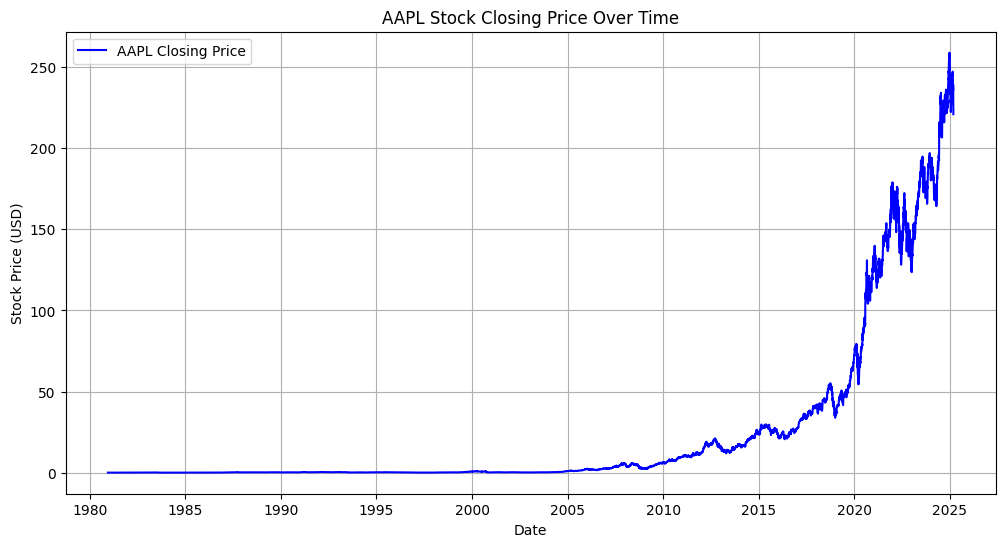

```python
plt.figure(figsize=(12, 6))
plt.plot(aapl_data.index, aapl_data['Close'], label="AAPL Closing Price", color='blue')
plt.title("AAPL Stock Closing Price Over Time")
plt.xlabel("Date")
plt.ylabel("Stock Price (USD)")
plt.legend()
plt.grid()
plt.show()
```

We can see a significant growth in the long-term period. We also can see the periods of high volatility.

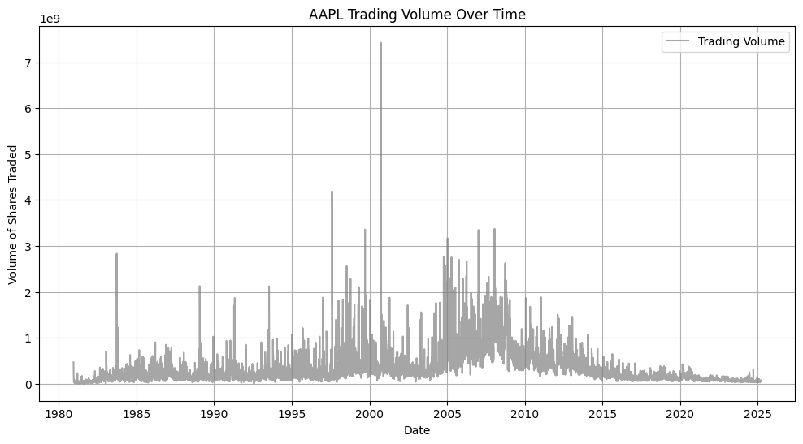

```python
plt.figure(figsize=(12, 6))
plt.plot(aapl_data.index, aapl_data['Volume'], color='gray', alpha=0.7, label="Trading Volume")
plt.title("AAPL Trading Volume Over Time")
plt.xlabel("Date")
plt.ylabel("Volume of Shares Traded")
plt.legend()
plt.grid()
plt.show()
```

Now, let's see some rolling statistics and moving averages. A moving average (MA) smooths out price fluctuations and helps identify trends.

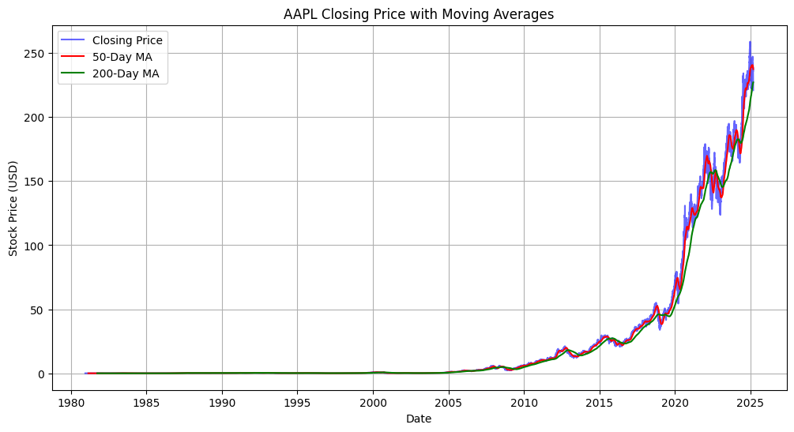

```python
aapl_data['MA50'] = aapl_data['Close'].rolling(window=50).mean()
aapl_data['MA200'] = aapl_data['Close'].rolling(window=200).mean()

plt.figure(figsize=(12, 6))
plt.plot(aapl_data.index, aapl_data['Close'], label="Closing Price", color='blue', alpha=0.6)
plt.plot(aapl_data.index, aapl_data['MA50'], label="50-Day MA", color='red')
plt.plot(aapl_data.index, aapl_data['MA200'], label="200-Day MA", color='green')
plt.title("AAPL Closing Price with Moving Averages")
plt.xlabel("Date")
plt.ylabel("Stock Price (USD)")
plt.legend()
plt.grid()
plt.show()
```

The 50-day MA represents short-term trends. The 200-day MA represents the long-term trends. When the 50-day MA crosees above the 200-day MA (Golden Cross), it signals a potential bullish trend. A bullish trend in the prices of an industry's stocks is an upward trend, characterized by high investor confidence. When the 50-day MA crosees belowe the 200-day MA (Death Cross), it signals a bearish trend. The bearish trend indicates a downward trend in the prices. This trend is characterized by heavy investor pessimism.

Next, we will see the stock price volatility. This measures how much the stock price fluctuates over time.

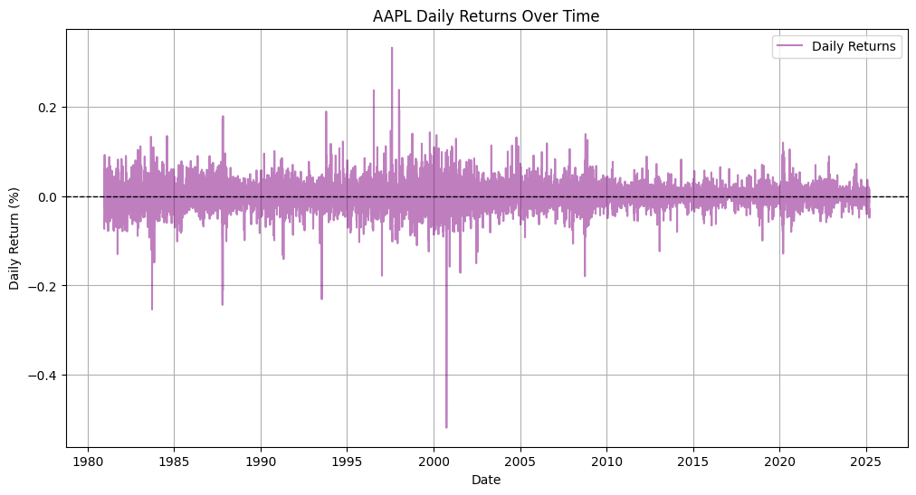

```python
aapl_data['Daily Return'] = aapl_data['Close'].pct_change()

plt.figure(figsize=(12, 6))
plt.plot(aapl_data.index, aapl_data['Daily Return'], label="Daily Returns", color='purple', alpha=0.5)
plt.axhline(0, color='black', linestyle='dashed', linewidth=1)
plt.title("AAPL Daily Returns Over Time")
plt.xlabel("Date")
plt.ylabel("Daily Return (%)")
plt.legend()
plt.grid()
plt.show()
```

We can see the daily returns over time where the large spikes indicate high volatility days. The stable periods suggest low-risk market conditions.

Now, we will plot the daily return distribution. A histogram of daily returns show the distribution of stock price changes.

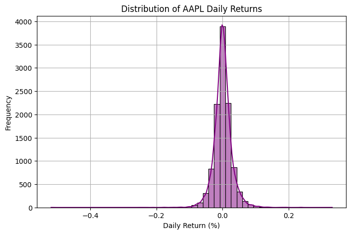

```python
plt.figure(figsize=(8, 5))
sns.histplot(aapl_data['Daily Return'].dropna(), bins=50, kde=True, color='purple')
plt.title("Distribution of AAPL Daily Returns")
plt.xlabel("Daily Return (%)")
plt.ylabel("Frequency")
plt.grid()
plt.show()
```

A normal distribution suggests stable market conditions. Long tails indicate large price swings, aka high volatility.

In the correlation analysis below, we can see the correlations between stock prices. We have high correlation between Open, High, Low, Close. The Volume has lower correlation with the prices.

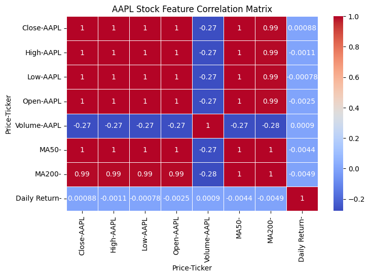

```python
plt.figure(figsize=(8, 5))
sns.heatmap(aapl_data.corr(), annot=True, cmap="coolwarm", linewidths=0.5)
plt.title("AAPL Stock Feature Correlation Matrix")
plt.show()
```

#### Key Takeaways

1. AAPL stocj shows long-term growth with short-term fluctuations.
2. Stock prices follow trends, identified by moving averages.
3. Daily returns suggest a mostly normal distribution but with occasional volatility.

### 🛠️ Data Preparation

Now that we understood the dataset, the next step is Data Preparation, where we clean and prepare the data before feeding it into our neural network.

Currently, we have some additional columns that we have added during the exploration phase. Since these columns are not essential for the ANN, we should remove them.

```python
aapl_data = aapl_data.drop(columns=['MA50', 'MA200', 'Daily Return'], errors='ignore')

print(aapl_data.head())
```

```
Price          Close      High       Low      Open     Volume
Ticker          AAPL      AAPL      AAPL      AAPL       AAPL
Date
1980-12-12  0.098726  0.099155  0.098726  0.098726  469033600
1980-12-15  0.093575  0.094005  0.093575  0.094005  175884800
1980-12-16  0.086707  0.087136  0.086707  0.087136  105728000
1980-12-17  0.088853  0.089282  0.088853  0.088853   86441600
1980-12-18  0.091429  0.091858  0.091429  0.091429   73449600
```

From our previous analysis, we notices that the volume's minimum value is 0. This is unusual because zero volume suggests no trading happened. This is likely due to holidays or market shutdowns. Such days may not contribute useful learning signals for the ANN.

```python
volume_col = ('Volume', 'AAPL') if ('Volume', 'AAPL') in aapl_data.columns else 'Volume'

zero_volume_days = aapl_data[aapl_data[volume_col] == 0]
print("Days with Zero Volume:", zero_volume_days.shape[0])

print(zero_volume_days.head())
```

```
Days with Zero Volume: 1
Price          Close      High       Low      Open Volume
Ticker          AAPL      AAPL      AAPL      AAPL   AAPL
Date
1981-08-10  0.086707  0.086707  0.086707  0.086707      0
```

As we can see, there is just one day with 0 volume. The date is 1981-08-10. It is likey due to missing or incomplete historical data rather an actual cessation of trading on that day. Given that this is an isolated incident, it is best to remove the entry from the dataset to maintain data integrity.

```python
aapl_data = aapl_data[aapl_data[volume_col] > 0]

print("Remaining Zero Volume Days:", (aapl_data[volume_col] == 0).sum())
```

```
Remaining Zero Volume Days: 0
```

```python
print(aapl_data.head())
```

```
Price          Close      High       Low      Open     Volume
Ticker          AAPL      AAPL      AAPL      AAPL       AAPL
Date
1980-12-12  0.098726  0.099155  0.098726  0.098726  469033600
1980-12-15  0.093575  0.094005  0.093575  0.094005  175884800
1980-12-16  0.086707  0.087136  0.086707  0.087136  105728000
1980-12-17  0.088853  0.089282  0.088853  0.088853   86441600
1980-12-18  0.091429  0.091858  0.091429  0.091429   73449600
```

## 🔮 Predictions

### Modeling Plan

We'll experiment with 4 different models, from simpler to more advanced to find the best performing ANN for this problem. The models are:

- Basic Feedforward ANN - A simple fully connected neural network (MLP) using only stock price features.
- Deep Feedforward ANN - A deeper ANN with more hidden layers and neurons to capture complex patterns.
- LSTM (Long Short-Term Memory) - An advanced recurrent neural network (RNN) that is well-suited for time-series forecasting.
- Bidirectional LSTM (BiLSTM) - A more advanced LSTM variant that processes stock price data both forward and backward, allowing the model to capture relationships in both past and future trends within the sequence window.

### Train-Test Split

Before modeling we need to split the data into a training set (to learn patterns) and a test set (to evaluate performance).

```python
from sklearn.model_selection import train_test_split

X = aapl_data[['Open', 'High', 'Low', 'Volume']]  # features
y = aapl_data['Close']  # target variable (we want to predict the Close price)

# 80% train, 20% test
X_train, X_test, y_train, y_test = train_test_split(X, y, test_size=0.2, shuffle=False)

print("Training Set Shape:", X_train.shape, y_train.shape)
print("Test Set Shape:", X_test.shape, y_test.shape)
```

```
Training Set Shape: (8920, 4) (8920, 1)
Test Set Shape: (2230, 4) (2230, 1)
```

### 🔷 Basic Feedforward ANN (MLP)

#### 🧹 Preprocessing

Before training our ANN to predict stock prices, we need to preprocess the data to ensure the model learns efficiently. Since stock prices and trading volumes vary significantly in scale, we must normalize them to a smaller, uniform range. Neural networks perform best when input values are within a small range, such as 0 to 1, preventing large numbers from dominating the training process and leading to unstable learning. We use MinMaxScaler to normalize the input features (Open, High, Low, Volume) and target variable (Close price) to a standardized range. The scaler is fitted on the training data and applied consistently to both training and test sets. Since MinMaxScaler requires a 2D array, we reshape the target variable before scaling and convert all datasets into NumPy arrays to ensure compatibility with TensorFlow.

```python
scaler_X = MinMaxScaler()
scaler_y = MinMaxScaler()

X_train_scaled = scaler_X.fit_transform(X_train)
X_test_scaled = scaler_X.transform(X_test)

y_train_scaled = scaler_y.fit_transform(y_train.values.reshape(-1, 1))
y_test_scaled = scaler_y.transform(y_test.values.reshape(-1, 1))

X_train_array = np.array(X_train_scaled)
X_test_array = np.array(X_test_scaled)
y_train_array = np.array(y_train_scaled)
y_test_array = np.array(y_test_scaled)
```

#### 🧬 Modelling

We are going to build a basic fully connected neural network with:

- Input layer: 4 features (Open, High, Low, Volume)
- Hidden layers: 2 layers with ReLU activation.
- Output layer: 1 neuron (to predict Close price)

The first hidden layer has 64 neurons and uses the ReLU (Rectified Linear Unit) activation function, which helps the model learn complex patterns by introducing non-linearity while preventing the vanishing gradient problem. The second hidden layer follows a similar structure but with 32 neurons, reducing the dimensionality and focusing on more refined feature extraction. The final output layer has one neuron with a linear activation, as this is a regression task predicting a continuous stock price. The model is compiled using the Adam optimizer, which adapts the learning rate dynamically for efficient training.

```python
model1 = keras.Sequential([
    layers.Dense(64, activation='relu', input_shape=(X_train.shape[1],)),
    layers.Dense(32, activation='relu'),
    layers.Dense(1)
])

model1.compile(optimizer=Adam(learning_rate=0.001), loss='mse', metrics=['mae'])

model1.summary()
```

```
Model: "sequential_7"
```

```
┏━━━━━━━━━━━━━━━━━━━━━━━━━━━━━━━━━┳━━━━━━━━━━━━━━━━━━━━━━━━┳━━━━━━━━━━━━━━━┓
┃ Layer (type)                    ┃ Output Shape           ┃       Param # ┃
┡━━━━━━━━━━━━━━━━━━━━━━━━━━━━━━━━━╇━━━━━━━━━━━━━━━━━━━━━━━━╇━━━━━━━━━━━━━━━┩
│ dense_33 (Dense)                │ (None, 64)             │           320 │
├─────────────────────────────────┼────────────────────────┼───────────────┤
│ dense_34 (Dense)                │ (None, 32)             │         2,080 │
├─────────────────────────────────┼────────────────────────┼───────────────┤
│ dense_35 (Dense)                │ (None, 1)              │            33 │
└─────────────────────────────────┴────────────────────────┴───────────────┘
```

```
 Total params: 2,433 (9.50 KB)
```

```
 Trainable params: 2,433 (9.50 KB)
```

```
 Non-trainable params: 0 (0.00 B)
```

With the next line of code, we are going to train the ANN for 50 epochs using a batch size of 32, meaning the model updates its weights after processing every 32 samples.

```python
history1 = model1.fit(X_train_array, y_train_array, epochs=50, batch_size=32, validation_split=0.2, verbose=1)
```

```
223/223 ━━━━━━━━━━━━━━━━━━━━ 1s 2ms/step - loss: 1.2891e-04 - mae: 0.0053 - val_loss: 0.0135 - val_mae: 0.0931
223/223 ━━━━━━━━━━━━━━━━━━━━ 0s 1ms/step - loss: 1.0129e-06 - mae: 5.4661e-04 - val_loss: 0.0131 - val_mae: 0.0916
223/223 ━━━━━━━━━━━━━━━━━━━━ 0s 1ms/step - loss: 8.4909e-07 - mae: 5.4952e-04 - val_loss: 0.0116 - val_mae: 0.0852
223/223 ━━━━━━━━━━━━━━━━━━━━ 0s 1ms/step - loss: 1.0962e-06 - mae: 6.1048e-04 - val_loss: 0.0108 - val_mae: 0.0815
223/223 ━━━━━━━━━━━━━━━━━━━━ 0s 1ms/step - loss: 8.8053e-07 - mae: 5.4386e-04 - val_loss: 0.0107 - val_mae: 0.0811
223/223 ━━━━━━━━━━━━━━━━━━━━ 0s 1ms/step - loss: 9.4067e-07 - mae: 6.1659e-04 - val_loss: 0.0108 - val_mae: 0.0814
223/223 ━━━━━━━━━━━━━━━━━━━━ 0s 1ms/step - loss: 1.0627e-06 - mae: 6.6867e-04 - val_loss: 0.0102 - val_mae: 0.0790
223/223 ━━━━━━━━━━━━━━━━━━━━ 0s 2ms/step - loss: 1.2721e-06 - mae: 6.8955e-04 - val_loss: 0.0114 - val_mae: 0.0844
223/223 ━━━━━━━━━━━━━━━━━━━━ 0s 1ms/step - loss: 9.8115e-07 - mae: 5.9622e-04 - val_loss: 0.0105 - val_mae: 0.0804
223/223 ━━━━━━━━━━━━━━━━━━━━ 0s 1ms/step - loss: 1.1198e-06 - mae: 6.6869e-04 - val_loss: 0.0110 - val_mae: 0.0829
223/223 ━━━━━━━━━━━━━━━━━━━━ 0s 1ms/step - loss: 9.9630e-07 - mae: 6.5708e-04 - val_loss: 0.0106 - val_mae: 0.0811
223/223 ━━━━━━━━━━━━━━━━━━━━ 0s 1ms/step - loss: 1.1494e-06 - mae: 7.0808e-04 - val_loss: 0.0098 - val_mae: 0.0777
223/223 ━━━━━━━━━━━━━━━━━━━━ 1s 3ms/step - loss: 1.3766e-06 - mae: 8.2818e-04 - val_loss: 0.0077 - val_mae: 0.0673
223/223 ━━━━━━━━━━━━━━━━━━━━ 0s 1ms/step - loss: 1.1700e-06 - mae: 6.4981e-04 - val_loss: 0.0103 - val_mae: 0.0797
223/223 ━━━━━━━━━━━━━━━━━━━━ 0s 1ms/step - loss: 9.7165e-07 - mae: 5.9680e-04 - val_loss: 0.0101 - val_mae: 0.0789
223/223 ━━━━━━━━━━━━━━━━━━━━ 0s 2ms/step - loss: 8.9159e-07 - mae: 5.9771e-04 - val_loss: 0.0087 - val_mae: 0.0726
223/223 ━━━━━━━━━━━━━━━━━━━━ 0s 2ms/step - loss: 9.6949e-07 - mae: 6.4159e-04 - val_loss: 0.0070 - val_mae: 0.0647
223/223 ━━━━━━━━━━━━━━━━━━━━ 0s 1ms/step - loss: 1.2572e-06 - mae: 7.3623e-04 - val_loss: 0.0072 - val_mae: 0.0655
223/223 ━━━━━━━━━━━━━━━━━━━━ 0s 1ms/step - loss: 1.2488e-06 - mae: 6.7936e-04 - val_loss: 0.0075 - val_mae: 0.0680
223/223 ━━━━━━━━━━━━━━━━━━━━ 0s 1ms/step - loss: 1.1271e-06 - mae: 6.7064e-04 - val_loss: 0.0068 - val_mae: 0.0639
223/223 ━━━━━━━━━━━━━━━━━━━━ 0s 1ms/step - loss: 1.4927e-06 - mae: 7.6730e-04 - val_loss: 0.0075 - val_mae: 0.0680
223/223 ━━━━━━━━━━━━━━━━━━━━ 0s 1ms/step - loss: 1.0614e-06 - mae: 6.1037e-04 - val_loss: 0.0077 - val_mae: 0.0692
223/223 ━━━━━━━━━━━━━━━━━━━━ 0s 1ms/step - loss: 8.1278e-07 - mae: 5.2923e-04 - val_loss: 0.0074 - val_mae: 0.0671
223/223 ━━━━━━━━━━━━━━━━━━━━ 0s 1ms/step - loss: 7.3903e-07 - mae: 5.3107e-04 - val_loss: 0.0078 - val_mae: 0.0691
223/223 ━━━━━━━━━━━━━━━━━━━━ 0s 1ms/step - loss: 8.4421e-07 - mae: 5.9705e-04 - val_loss: 0.0065 - val_mae: 0.0628
223/223 ━━━━━━━━━━━━━━━━━━━━ 0s 1ms/step - loss: 7.2394e-07 - mae: 5.2260e-04 - val_loss: 0.0079 - val_mae: 0.0700
223/223 ━━━━━━━━━━━━━━━━━━━━ 0s 1ms/step - loss: 9.6463e-07 - mae: 6.0819e-04 - val_loss: 0.0062 - val_mae: 0.0615
223/223 ━━━━━━━━━━━━━━━━━━━━ 0s 1ms/step - loss: 7.7097e-07 - mae: 5.1031e-04 - val_loss: 0.0065 - val_mae: 0.0631
223/223 ━━━━━━━━━━━━━━━━━━━━ 0s 1ms/step - loss: 8.4597e-07 - mae: 5.4884e-04 - val_loss: 0.0068 - val_mae: 0.0644
223/223 ━━━━━━━━━━━━━━━━━━━━ 0s 2ms/step - loss: 9.9193e-07 - mae: 6.5164e-04 - val_loss: 0.0062 - val_mae: 0.0609
223/223 ━━━━━━━━━━━━━━━━━━━━ 0s 1ms/step - loss: 1.3154e-06 - mae: 7.0480e-04 - val_loss: 0.0059 - val_mae: 0.0595
223/223 ━━━━━━━━━━━━━━━━━━━━ 0s 2ms/step - loss: 8.0598e-07 - mae: 5.6929e-04 - val_loss: 0.0068 - val_mae: 0.0647
223/223 ━━━━━━━━━━━━━━━━━━━━ 0s 1ms/step - loss: 8.1469e-07 - mae: 5.3484e-04 - val_loss: 0.0068 - val_mae: 0.0650
223/223 ━━━━━━━━━━━━━━━━━━━━ 0s 1ms/step - loss: 6.6781e-07 - mae: 4.9980e-04 - val_loss: 0.0060 - val_mae: 0.0607
223/223 ━━━━━━━━━━━━━━━━━━━━ 0s 1ms/step - loss: 9.8042e-07 - mae: 6.4991e-04 - val_loss: 0.0059 - val_mae: 0.0597
223/223 ━━━━━━━━━━━━━━━━━━━━ 0s 1ms/step - loss: 7.4357e-07 - mae: 5.5935e-04 - val_loss: 0.0076 - val_mae: 0.0695
223/223 ━━━━━━━━━━━━━━━━━━━━ 0s 2ms/step - loss: 8.1987e-07 - mae: 5.4542e-04 - val_loss: 0.0054 - val_mae: 0.0572
223/223 ━━━━━━━━━━━━━━━━━━━━ 0s 1ms/step - loss: 7.4054e-07 - mae: 5.4687e-04 - val_loss: 0.0070 - val_mae: 0.0665
223/223 ━━━━━━━━━━━━━━━━━━━━ 0s 1ms/step - loss: 7.3494e-07 - mae: 5.3954e-04 - val_loss: 0.0060 - val_mae: 0.0608
223/223 ━━━━━━━━━━━━━━━━━━━━ 0s 1ms/step - loss: 9.0885e-07 - mae: 5.5967e-04 - val_loss: 0.0058 - val_mae: 0.0596
223/223 ━━━━━━━━━━━━━━━━━━━━ 0s 1ms/step - loss: 6.0319e-07 - mae: 4.5737e-04 - val_loss: 0.0059 - val_mae: 0.0600
223/223 ━━━━━━━━━━━━━━━━━━━━ 0s 2ms/step - loss: 9.1721e-07 - mae: 6.5796e-04 - val_loss: 0.0058 - val_mae: 0.0598
223/223 ━━━━━━━━━━━━━━━━━━━━ 0s 1ms/step - loss: 9.0465e-07 - mae: 5.9499e-04 - val_loss: 0.0061 - val_mae: 0.0617
223/223 ━━━━━━━━━━━━━━━━━━━━ 0s 1ms/step - loss: 8.9996e-07 - mae: 5.5286e-04 - val_loss: 0.0064 - val_mae: 0.0631
223/223 ━━━━━━━━━━━━━━━━━━━━ 0s 1ms/step - loss: 7.5789e-07 - mae: 5.4744e-04 - val_loss: 0.0059 - val_mae: 0.0606
223/223 ━━━━━━━━━━━━━━━━━━━━ 0s 1ms/step - loss: 6.5865e-07 - mae: 5.0192e-04 - val_loss: 0.0052 - val_mae: 0.0561
223/223 ━━━━━━━━━━━━━━━━━━━━ 0s 1ms/step - loss: 6.6332e-07 - mae: 4.7295e-04 - val_loss: 0.0048 - val_mae: 0.0541
223/223 ━━━━━━━━━━━━━━━━━━━━ 0s 2ms/step - loss: 8.4882e-07 - mae: 5.8161e-04 - val_loss: 0.0050 - val_mae: 0.0552
223/223 ━━━━━━━━━━━━━━━━━━━━ 0s 1ms/step - loss: 6.7569e-07 - mae: 5.2089e-04 - val_loss: 0.0049 - val_mae: 0.0549
223/223 ━━━━━━━━━━━━━━━━━━━━ 0s 1ms/step - loss: 7.1555e-07 - mae: 5.3308e-04 - val_loss: 0.0055 - val_mae: 0.0587
```

#### 🧐 Evaluation

```python
test_loss, test_mae = model1.evaluate(X_test_array, y_test_array)

print(f"Test MAE: {test_mae}")
print(f"Test MSE: {test_loss}")
```

```
70/70 ━━━━━━━━━━━━━━━━━━━━ 0s 1ms/step - loss: 0.1848 - mae: 0.3254
Test MAE: 0.6386889815330505
Test MSE: 0.5812966227531433
```

```
70/70 ━━━━━━━━━━━━━━━━━━━━ 0s 1ms/step
```

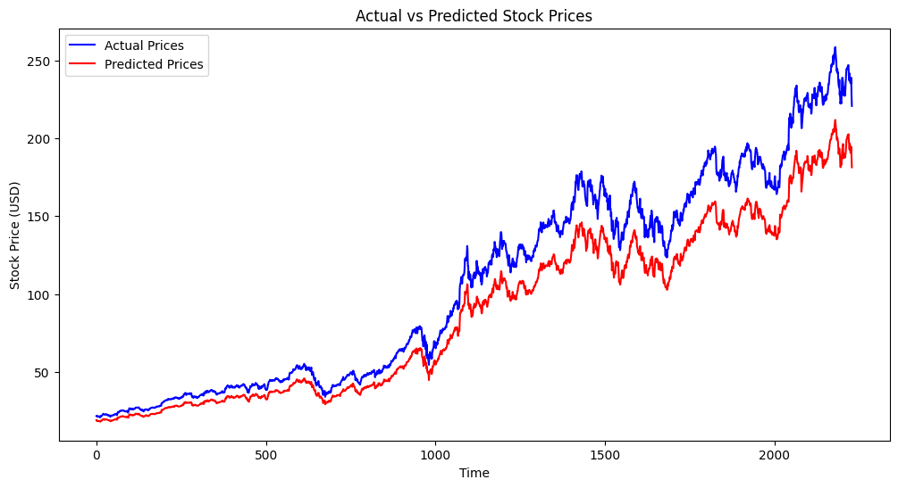

```python
y_pred_scaled = model1.predict(X_test_array)

y_pred = scaler_y.inverse_transform(y_pred_scaled)
y_actual = scaler_y.inverse_transform(y_test_scaled)

plt.figure(figsize=(12,6))
plt.plot(y_actual, label="Actual Prices", color='blue')
plt.plot(y_pred, label="Predicted Prices", color='red')
plt.title("Actual vs Predicted Stock Prices")
plt.xlabel("Time")
plt.ylabel("Stock Price (USD)")
plt.legend()
plt.show()
```

### 🔷 Deep Feedforward ANN

#### 🧬 Modelling

```python
model2 = keras.Sequential([
    layers.Dense(256, activation='relu', input_shape=(X_train_scaled.shape[1],)),
    layers.Dropout(0.1),

    layers.Dense(128, activation='relu'),
    layers.Dropout(0.2),

    layers.Dense(64, activation='relu'),
    layers.Dropout(0.2),

    layers.Dense(32, activation='relu'),
    layers.Dropout(0.2),

    layers.Dense(16, activation='relu'),

    layers.Dense(1)
])

model2.compile(optimizer=Adam(learning_rate=0.001), loss='mse', metrics=['mae'])

model2.summary()
```

```
Model: "sequential_3"
```

```
┏━━━━━━━━━━━━━━━━━━━━━━━━━━━━━━━━━┳━━━━━━━━━━━━━━━━━━━━━━━━┳━━━━━━━━━━━━━━━┓
┃ Layer (type)                    ┃ Output Shape           ┃       Param # ┃
┡━━━━━━━━━━━━━━━━━━━━━━━━━━━━━━━━━╇━━━━━━━━━━━━━━━━━━━━━━━━╇━━━━━━━━━━━━━━━┩
│ dense_3 (Dense)                 │ (None, 256)            │         1,280 │
├─────────────────────────────────┼────────────────────────┼───────────────┤
│ dropout_4 (Dropout)             │ (None, 256)            │             0 │
├─────────────────────────────────┼────────────────────────┼───────────────┤
│ dense_4 (Dense)                 │ (None, 128)            │        32,896 │
├─────────────────────────────────┼────────────────────────┼───────────────┤
│ dropout_5 (Dropout)             │ (None, 128)            │             0 │
├─────────────────────────────────┼────────────────────────┼───────────────┤
│ dense_5 (Dense)                 │ (None, 64)             │         8,256 │
├─────────────────────────────────┼────────────────────────┼───────────────┤
│ dropout_6 (Dropout)             │ (None, 64)             │             0 │
├─────────────────────────────────┼────────────────────────┼───────────────┤
│ dense_6 (Dense)                 │ (None, 32)             │         2,080 │
├─────────────────────────────────┼────────────────────────┼───────────────┤
│ dropout_7 (Dropout)             │ (None, 32)             │             0 │
├─────────────────────────────────┼────────────────────────┼───────────────┤
│ dense_7 (Dense)                 │ (None, 16)             │           528 │
├─────────────────────────────────┼────────────────────────┼───────────────┤
│ dense_8 (Dense)                 │ (None, 1)              │            17 │
└─────────────────────────────────┴────────────────────────┴───────────────┘
```

```
 Total params: 45,057 (176.00 KB)
```

```
 Trainable params: 45,057 (176.00 KB)
```

```
 Non-trainable params: 0 (0.00 B)
```

```python
history2 = model2.fit(X_train_scaled, y_train_scaled, epochs=100, batch_size=32, validation_split=0.2, verbose=1)
```

```
223/223 ━━━━━━━━━━━━━━━━━━━━ 2s 2ms/step - loss: 3.3528e-04 - mae: 0.0096 - val_loss: 0.0064 - val_mae: 0.0693
223/223 ━━━━━━━━━━━━━━━━━━━━ 0s 1ms/step - loss: 8.2009e-05 - mae: 0.0052 - val_loss: 0.0245 - val_mae: 0.1419
223/223 ━━━━━━━━━━━━━━━━━━━━ 0s 1ms/step - loss: 6.0722e-05 - mae: 0.0046 - val_loss: 0.0146 - val_mae: 0.1084
223/223 ━━━━━━━━━━━━━━━━━━━━ 0s 1ms/step - loss: 5.2484e-05 - mae: 0.0043 - val_loss: 0.0298 - val_mae: 0.1546
223/223 ━━━━━━━━━━━━━━━━━━━━ 0s 1ms/step - loss: 4.7686e-05 - mae: 0.0042 - val_loss: 0.0256 - val_mae: 0.1413
223/223 ━━━━━━━━━━━━━━━━━━━━ 0s 1ms/step - loss: 3.8287e-05 - mae: 0.0037 - val_loss: 0.0293 - val_mae: 0.1527
223/223 ━━━━━━━━━━━━━━━━━━━━ 0s 1ms/step - loss: 3.5052e-05 - mae: 0.0033 - val_loss: 0.0369 - val_mae: 0.1703
223/223 ━━━━━━━━━━━━━━━━━━━━ 0s 2ms/step - loss: 2.7916e-05 - mae: 0.0030 - val_loss: 0.0346 - val_mae: 0.1634
223/223 ━━━━━━━━━━━━━━━━━━━━ 0s 2ms/step - loss: 3.1451e-05 - mae: 0.0034 - val_loss: 0.0297 - val_mae: 0.1515
223/223 ━━━━━━━━━━━━━━━━━━━━ 0s 2ms/step - loss: 2.7212e-05 - mae: 0.0031 - val_loss: 0.0346 - val_mae: 0.1633
223/223 ━━━━━━━━━━━━━━━━━━━━ 0s 1ms/step - loss: 2.1446e-05 - mae: 0.0027 - val_loss: 0.0234 - val_mae: 0.1343
223/223 ━━━━━━━━━━━━━━━━━━━━ 0s 1ms/step - loss: 2.7515e-05 - mae: 0.0032 - val_loss: 0.0340 - val_mae: 0.1611
223/223 ━━━━━━━━━━━━━━━━━━━━ 0s 2ms/step - loss: 2.0815e-05 - mae: 0.0027 - val_loss: 0.0302 - val_mae: 0.1512
223/223 ━━━━━━━━━━━━━━━━━━━━ 0s 1ms/step - loss: 2.0693e-05 - mae: 0.0028 - val_loss: 0.0309 - val_mae: 0.1520
223/223 ━━━━━━━━━━━━━━━━━━━━ 0s 1ms/step - loss: 2.7272e-05 - mae: 0.0033 - val_loss: 0.0349 - val_mae: 0.1622
223/223 ━━━━━━━━━━━━━━━━━━━━ 0s 1ms/step - loss: 2.3473e-05 - mae: 0.0028 - val_loss: 0.0284 - val_mae: 0.1446
223/223 ━━━━━━━━━━━━━━━━━━━━ 0s 2ms/step - loss: 1.6870e-05 - mae: 0.0024 - val_loss: 0.0307 - val_mae: 0.1517
223/223 ━━━━━━━━━━━━━━━━━━━━ 0s 2ms/step - loss: 2.2161e-05 - mae: 0.0028 - val_loss: 0.0251 - val_mae: 0.1367
223/223 ━━━━━━━━━━━━━━━━━━━━ 0s 2ms/step - loss: 2.2106e-05 - mae: 0.0028 - val_loss: 0.0121 - val_mae: 0.0935
223/223 ━━━━━━━━━━━━━━━━━━━━ 0s 2ms/step - loss: 2.8388e-05 - mae: 0.0032 - val_loss: 0.0198 - val_mae: 0.1226
223/223 ━━━━━━━━━━━━━━━━━━━━ 0s 2ms/step - loss: 1.7887e-05 - mae: 0.0025 - val_loss: 0.0245 - val_mae: 0.1338
223/223 ━━━━━━━━━━━━━━━━━━━━ 0s 2ms/step - loss: 2.0186e-05 - mae: 0.0028 - val_loss: 0.0412 - val_mae: 0.1751
223/223 ━━━━━━━━━━━━━━━━━━━━ 0s 2ms/step - loss: 1.9858e-05 - mae: 0.0026 - val_loss: 0.0300 - val_mae: 0.1509
223/223 ━━━━━━━━━━━━━━━━━━━━ 0s 2ms/step - loss: 1.5183e-05 - mae: 0.0024 - val_loss: 0.0107 - val_mae: 0.0897
223/223 ━━━━━━━━━━━━━━━━━━━━ 0s 2ms/step - loss: 1.6206e-05 - mae: 0.0024 - val_loss: 0.0478 - val_mae: 0.1896
223/223 ━━━━━━━━━━━━━━━━━━━━ 0s 2ms/step - loss: 1.8783e-05 - mae: 0.0027 - val_loss: 0.0321 - val_mae: 0.1556
223/223 ━━━━━━━━━━━━━━━━━━━━ 0s 2ms/step - loss: 1.7366e-05 - mae: 0.0025 - val_loss: 0.0130 - val_mae: 0.0986
223/223 ━━━━━━━━━━━━━━━━━━━━ 0s 2ms/step - loss: 1.8098e-05 - mae: 0.0027 - val_loss: 0.0261 - val_mae: 0.1389
223/223 ━━━━━━━━━━━━━━━━━━━━ 0s 2ms/step - loss: 1.9712e-05 - mae: 0.0027 - val_loss: 0.0419 - val_mae: 0.1755
223/223 ━━━━━━━━━━━━━━━━━━━━ 0s 2ms/step - loss: 1.6939e-05 - mae: 0.0024 - val_loss: 0.0378 - val_mae: 0.1680
223/223 ━━━━━━━━━━━━━━━━━━━━ 0s 2ms/step - loss: 1.5225e-05 - mae: 0.0024 - val_loss: 0.0426 - val_mae: 0.1776
223/223 ━━━━━━━━━━━━━━━━━━━━ 1s 2ms/step - loss: 1.6011e-05 - mae: 0.0024 - val_loss: 0.0044 - val_mae: 0.0562
223/223 ━━━━━━━━━━━━━━━━━━━━ 0s 2ms/step - loss: 1.4669e-05 - mae: 0.0024 - val_loss: 0.0430 - val_mae: 0.1788
223/223 ━━━━━━━━━━━━━━━━━━━━ 0s 2ms/step - loss: 1.4029e-05 - mae: 0.0023 - val_loss: 0.0242 - val_mae: 0.1335
223/223 ━━━━━━━━━━━━━━━━━━━━ 0s 2ms/step - loss: 1.4474e-05 - mae: 0.0023 - val_loss: 0.0364 - val_mae: 0.1639
223/223 ━━━━━━━━━━━━━━━━━━━━ 0s 2ms/step - loss: 1.6847e-05 - mae: 0.0025 - val_loss: 0.0161 - val_mae: 0.1082
223/223 ━━━━━━━━━━━━━━━━━━━━ 0s 2ms/step - loss: 1.6792e-05 - mae: 0.0025 - val_loss: 0.0095 - val_mae: 0.0816
223/223 ━━━━━━━━━━━━━━━━━━━━ 0s 2ms/step - loss: 1.6528e-05 - mae: 0.0025 - val_loss: 0.0161 - val_mae: 0.1085
223/223 ━━━━━━━━━━━━━━━━━━━━ 0s 2ms/step - loss: 1.5220e-05 - mae: 0.0024 - val_loss: 0.0341 - val_mae: 0.1589
223/223 ━━━━━━━━━━━━━━━━━━━━ 0s 2ms/step - loss: 1.7185e-05 - mae: 0.0024 - val_loss: 0.0041 - val_mae: 0.0579
```

[output cut: 45 more lines]

```
223/223 ━━━━━━━━━━━━━━━━━━━━ 0s 2ms/step - loss: 1.2280e-05 - mae: 0.0021 - val_loss: 0.0294 - val_mae: 0.1460
223/223 ━━━━━━━━━━━━━━━━━━━━ 0s 2ms/step - loss: 1.1581e-05 - mae: 0.0021 - val_loss: 0.0281 - val_mae: 0.1429
223/223 ━━━━━━━━━━━━━━━━━━━━ 0s 2ms/step - loss: 1.0609e-05 - mae: 0.0020 - val_loss: 0.0317 - val_mae: 0.1515
223/223 ━━━━━━━━━━━━━━━━━━━━ 0s 2ms/step - loss: 1.0084e-05 - mae: 0.0020 - val_loss: 0.0280 - val_mae: 0.1430
223/223 ━━━━━━━━━━━━━━━━━━━━ 0s 2ms/step - loss: 1.0770e-05 - mae: 0.0020 - val_loss: 0.0195 - val_mae: 0.1213
223/223 ━━━━━━━━━━━━━━━━━━━━ 0s 2ms/step - loss: 1.0805e-05 - mae: 0.0021 - val_loss: 0.0080 - val_mae: 0.0783
223/223 ━━━━━━━━━━━━━━━━━━━━ 0s 2ms/step - loss: 9.8745e-06 - mae: 0.0020 - val_loss: 0.0622 - val_mae: 0.2131
223/223 ━━━━━━━━━━━━━━━━━━━━ 0s 2ms/step - loss: 8.8558e-06 - mae: 0.0018 - val_loss: 0.0272 - val_mae: 0.1413
223/223 ━━━━━━━━━━━━━━━━━━━━ 0s 2ms/step - loss: 9.7891e-06 - mae: 0.0019 - val_loss: 0.0147 - val_mae: 0.1040
223/223 ━━━━━━━━━━━━━━━━━━━━ 0s 2ms/step - loss: 9.2812e-06 - mae: 0.0019 - val_loss: 0.0313 - val_mae: 0.1509
223/223 ━━━━━━━━━━━━━━━━━━━━ 0s 2ms/step - loss: 9.6942e-06 - mae: 0.0020 - val_loss: 0.0837 - val_mae: 0.2456
223/223 ━━━━━━━━━━━━━━━━━━━━ 0s 2ms/step - loss: 1.0835e-05 - mae: 0.0020 - val_loss: 0.0219 - val_mae: 0.1266
223/223 ━━━━━━━━━━━━━━━━━━━━ 0s 2ms/step - loss: 9.2034e-06 - mae: 0.0019 - val_loss: 0.0662 - val_mae: 0.2185
223/223 ━━━━━━━━━━━━━━━━━━━━ 0s 2ms/step - loss: 9.2861e-06 - mae: 0.0019 - val_loss: 0.0172 - val_mae: 0.1114
223/223 ━━━━━━━━━━━━━━━━━━━━ 0s 2ms/step - loss: 1.0792e-05 - mae: 0.0019 - val_loss: 0.0184 - val_mae: 0.1172
```

#### 🧐 Evaluation

```python
test_loss2, test_mae2 = model2.evaluate(X_test_scaled, y_test_scaled)

print(f"Test MAE: {test_mae2}")
print(f"Test MSE: {test_loss2}")
```

```
70/70 ━━━━━━━━━━━━━━━━━━━━ 0s 1ms/step - loss: 0.4415 - mae: 0.5115
Test MAE: 0.9852942824363708
Test MSE: 1.3664199113845825
```

```
70/70 ━━━━━━━━━━━━━━━━━━━━ 0s 1ms/step
```

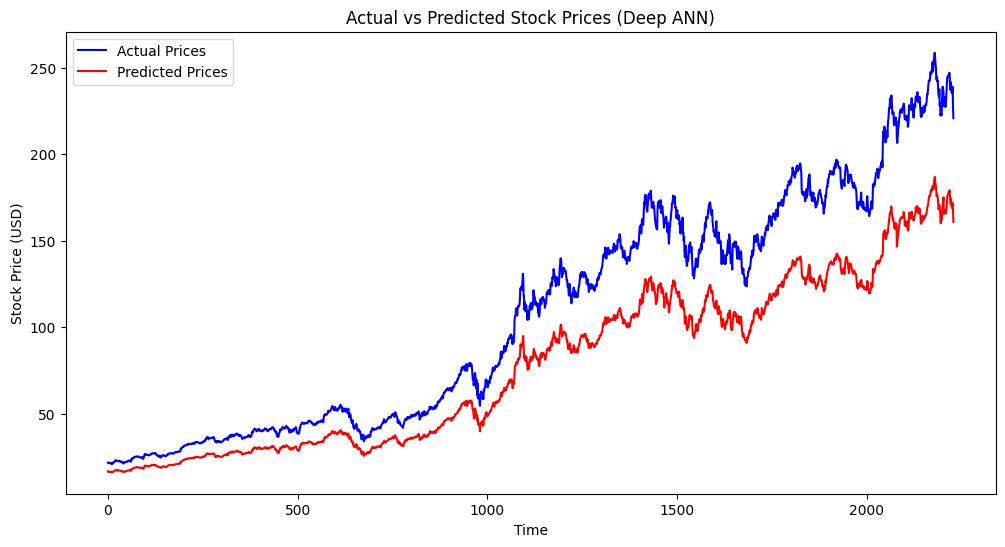

```python
y_pred2_scaled = model2.predict(X_test_scaled)

y_pred2 = scaler_y.inverse_transform(y_pred2_scaled)
y_actual2 = scaler_y.inverse_transform(y_test_scaled)

plt.figure(figsize=(12,6))
plt.plot(y_actual2, label="Actual Prices", color='blue')
plt.plot(y_pred2, label="Predicted Prices", color='red')
plt.title("Actual vs Predicted Stock Prices (Deep ANN)")
plt.xlabel("Time")
plt.ylabel("Stock Price (USD)")
plt.legend()
plt.show()
```

The model is able to follow the trend but not predict the price correctly. We are going to try to tune the hyperparameters to achieve an optimal result.

#### Hyperparameter Tuning for Feedforward ANN

```python
def build_deep_ann_model(hp):
    model = keras.Sequential()

    model.add(layers.Dense(hp.Int("units_1", min_value=32, max_value=256, step=32),
                           activation='relu', input_shape=(X_train_scaled.shape[1],)))

    for i in range(hp.Int("num_layers", 3, 6)):
        model.add(layers.Dense(hp.Int(f"units_{i+2}", min_value=32, max_value=256, step=32), activation="relu"))

        model.add(layers.Dropout(hp.Choice("dropout", [0.1, 0.2, 0.3])))

    model.add(layers.Dense(1))

    model.compile(
        optimizer=Adam(hp.Choice("learning_rate", [0.0001, 0.001, 0.01])),
        loss="mse",
        metrics=["mae"]
    )

    return model
```

After building the function to tune the hyperparameters, it is time to run the process using the Keras Tuner's Random Search. The tuner searches for the optimal combination of the hyperparameters by testing 10 different model configurations. Each configuration is evaluated twice to improve reliability. The tuning process optimizes the model based on the validation Mean Absolute Error (MAE).

```python
tuner_ann = kt.RandomSearch(
    build_deep_ann_model,
    objective="val_mae",
    max_trials=10,
    executions_per_trial=2,
    directory="hyperparameter_tuning",
    project_name="deep_ann_tuning"
)

tuner_ann.search(X_train_scaled, y_train_scaled, epochs=50, validation_split=0.2, batch_size=32, verbose=1)
```

```
Reloading Tuner from hyperparameter_tuning\deep_ann_tuning\tuner0.json
```

```python
best_hps_ann = tuner_ann.get_best_hyperparameters(num_trials=1)[0]

print(f"Best number of layers: {best_hps_ann.get('num_layers')}")
print(f"Best units for first layer: {best_hps_ann.get('units_1')}")
print(f"Best learning rate: {best_hps_ann.get('learning_rate')}")
print(f"Best dropout rate: {best_hps_ann.get('dropout')}")
```

```
Best number of layers: 3
Best units for first layer: 128
Best learning rate: 0.001
Best dropout rate: 0.1
```

```python
model_optimized_ann = keras.Sequential([
    layers.Dense(128, activation='relu', input_shape=(X_train_scaled.shape[1],)),
    layers.Dropout(0.1),

    layers.Dense(64, activation='relu'),
    layers.Dropout(0.1),

    layers.Dense(32, activation='relu'),
    layers.Dropout(0.1),

    layers.Dense(1)
])

model_optimized_ann.compile(optimizer=Adam(learning_rate=0.001), loss='mse', metrics=['mae'])

model_optimized_ann.summary()
```

```
Model: "sequential_13"
```

```
┏━━━━━━━━━━━━━━━━━━━━━━━━━━━━━━━━━┳━━━━━━━━━━━━━━━━━━━━━━━━┳━━━━━━━━━━━━━━━┓
┃ Layer (type)                    ┃ Output Shape           ┃       Param # ┃
┡━━━━━━━━━━━━━━━━━━━━━━━━━━━━━━━━━╇━━━━━━━━━━━━━━━━━━━━━━━━╇━━━━━━━━━━━━━━━┩
│ dense_52 (Dense)                │ (None, 128)            │           640 │
├─────────────────────────────────┼────────────────────────┼───────────────┤
│ dropout_33 (Dropout)            │ (None, 128)            │             0 │
├─────────────────────────────────┼────────────────────────┼───────────────┤
│ dense_53 (Dense)                │ (None, 64)             │         8,256 │
├─────────────────────────────────┼────────────────────────┼───────────────┤
│ dropout_34 (Dropout)            │ (None, 64)             │             0 │
├─────────────────────────────────┼────────────────────────┼───────────────┤
│ dense_54 (Dense)                │ (None, 32)             │         2,080 │
├─────────────────────────────────┼────────────────────────┼───────────────┤
│ dropout_35 (Dropout)            │ (None, 32)             │             0 │
├─────────────────────────────────┼────────────────────────┼───────────────┤
│ dense_55 (Dense)                │ (None, 1)              │            33 │
└─────────────────────────────────┴────────────────────────┴───────────────┘
```

```
 Total params: 11,009 (43.00 KB)
```

```
 Trainable params: 11,009 (43.00 KB)
```

```
 Non-trainable params: 0 (0.00 B)
```

```python
history_optimized_ann = model_optimized_ann.fit(X_train_scaled, y_train_scaled, epochs=100, batch_size=32, validation_split=0.2, verbose=1)
```

```
223/223 ━━━━━━━━━━━━━━━━━━━━ 1s 3ms/step - loss: 3.5470e-04 - mae: 0.0093 - val_loss: 4.9180e-04 - val_mae: 0.0178
223/223 ━━━━━━━━━━━━━━━━━━━━ 1s 2ms/step - loss: 5.3290e-05 - mae: 0.0039 - val_loss: 4.3173e-04 - val_mae: 0.0175
223/223 ━━━━━━━━━━━━━━━━━━━━ 0s 2ms/step - loss: 4.9779e-05 - mae: 0.0039 - val_loss: 8.5890e-04 - val_mae: 0.0252
223/223 ━━━━━━━━━━━━━━━━━━━━ 0s 2ms/step - loss: 4.8815e-05 - mae: 0.0041 - val_loss: 8.5851e-05 - val_mae: 0.0076
223/223 ━━━━━━━━━━━━━━━━━━━━ 0s 2ms/step - loss: 4.2746e-05 - mae: 0.0036 - val_loss: 9.8938e-04 - val_mae: 0.0273
223/223 ━━━━━━━━━━━━━━━━━━━━ 0s 1ms/step - loss: 4.3603e-05 - mae: 0.0037 - val_loss: 4.2632e-04 - val_mae: 0.0178
223/223 ━━━━━━━━━━━━━━━━━━━━ 0s 1ms/step - loss: 3.4106e-05 - mae: 0.0034 - val_loss: 0.0010 - val_mae: 0.0282
223/223 ━━━━━━━━━━━━━━━━━━━━ 0s 2ms/step - loss: 3.6822e-05 - mae: 0.0034 - val_loss: 5.9086e-04 - val_mae: 0.0208
223/223 ━━━━━━━━━━━━━━━━━━━━ 0s 2ms/step - loss: 3.3775e-05 - mae: 0.0033 - val_loss: 3.4500e-05 - val_mae: 0.0043
223/223 ━━━━━━━━━━━━━━━━━━━━ 0s 2ms/step - loss: 3.0224e-05 - mae: 0.0031 - val_loss: 0.0014 - val_mae: 0.0345
223/223 ━━━━━━━━━━━━━━━━━━━━ 1s 2ms/step - loss: 2.8128e-05 - mae: 0.0029 - val_loss: 0.0028 - val_mae: 0.0465
223/223 ━━━━━━━━━━━━━━━━━━━━ 0s 2ms/step - loss: 3.1991e-05 - mae: 0.0032 - val_loss: 1.0493e-04 - val_mae: 0.0091
223/223 ━━━━━━━━━━━━━━━━━━━━ 0s 1ms/step - loss: 3.0899e-05 - mae: 0.0030 - val_loss: 0.0029 - val_mae: 0.0467
223/223 ━━━━━━━━━━━━━━━━━━━━ 0s 1ms/step - loss: 3.2934e-05 - mae: 0.0032 - val_loss: 4.2827e-05 - val_mae: 0.0050
223/223 ━━━━━━━━━━━━━━━━━━━━ 0s 1ms/step - loss: 3.4987e-05 - mae: 0.0031 - val_loss: 7.8537e-04 - val_mae: 0.0248
223/223 ━━━━━━━━━━━━━━━━━━━━ 0s 1ms/step - loss: 3.4495e-05 - mae: 0.0032 - val_loss: 0.0019 - val_mae: 0.0391
223/223 ━━━━━━━━━━━━━━━━━━━━ 0s 1ms/step - loss: 3.2854e-05 - mae: 0.0030 - val_loss: 1.5666e-04 - val_mae: 0.0112
223/223 ━━━━━━━━━━━━━━━━━━━━ 0s 2ms/step - loss: 2.6136e-05 - mae: 0.0028 - val_loss: 7.3313e-04 - val_mae: 0.0221
223/223 ━━━━━━━━━━━━━━━━━━━━ 0s 2ms/step - loss: 3.3343e-05 - mae: 0.0030 - val_loss: 0.0014 - val_mae: 0.0331
223/223 ━━━━━━━━━━━━━━━━━━━━ 0s 2ms/step - loss: 2.8333e-05 - mae: 0.0029 - val_loss: 0.0072 - val_mae: 0.0757
223/223 ━━━━━━━━━━━━━━━━━━━━ 1s 2ms/step - loss: 3.4543e-05 - mae: 0.0031 - val_loss: 0.0015 - val_mae: 0.0337
223/223 ━━━━━━━━━━━━━━━━━━━━ 0s 2ms/step - loss: 2.9932e-05 - mae: 0.0030 - val_loss: 0.0033 - val_mae: 0.0515
223/223 ━━━━━━━━━━━━━━━━━━━━ 1s 2ms/step - loss: 2.8297e-05 - mae: 0.0030 - val_loss: 0.0028 - val_mae: 0.0465
223/223 ━━━━━━━━━━━━━━━━━━━━ 0s 2ms/step - loss: 2.9281e-05 - mae: 0.0031 - val_loss: 3.2470e-04 - val_mae: 0.0161
223/223 ━━━━━━━━━━━━━━━━━━━━ 0s 2ms/step - loss: 2.8720e-05 - mae: 0.0029 - val_loss: 4.8835e-04 - val_mae: 0.0193
223/223 ━━━━━━━━━━━━━━━━━━━━ 0s 2ms/step - loss: 2.4897e-05 - mae: 0.0028 - val_loss: 0.0025 - val_mae: 0.0436
223/223 ━━━━━━━━━━━━━━━━━━━━ 0s 2ms/step - loss: 2.6206e-05 - mae: 0.0028 - val_loss: 7.2417e-04 - val_mae: 0.0230
223/223 ━━━━━━━━━━━━━━━━━━━━ 0s 1ms/step - loss: 2.8733e-05 - mae: 0.0029 - val_loss: 9.4976e-04 - val_mae: 0.0254
223/223 ━━━━━━━━━━━━━━━━━━━━ 0s 2ms/step - loss: 2.3596e-05 - mae: 0.0028 - val_loss: 0.0049 - val_mae: 0.0621
223/223 ━━━━━━━━━━━━━━━━━━━━ 0s 2ms/step - loss: 3.1983e-05 - mae: 0.0029 - val_loss: 6.5629e-04 - val_mae: 0.0215
223/223 ━━━━━━━━━━━━━━━━━━━━ 0s 2ms/step - loss: 3.0765e-05 - mae: 0.0029 - val_loss: 0.0013 - val_mae: 0.0315
223/223 ━━━━━━━━━━━━━━━━━━━━ 0s 2ms/step - loss: 3.2299e-05 - mae: 0.0029 - val_loss: 0.0053 - val_mae: 0.0631
223/223 ━━━━━━━━━━━━━━━━━━━━ 0s 1ms/step - loss: 3.0677e-05 - mae: 0.0030 - val_loss: 0.0019 - val_mae: 0.0391
223/223 ━━━━━━━━━━━━━━━━━━━━ 0s 1ms/step - loss: 2.5256e-05 - mae: 0.0027 - val_loss: 0.0032 - val_mae: 0.0497
223/223 ━━━━━━━━━━━━━━━━━━━━ 0s 2ms/step - loss: 3.1274e-05 - mae: 0.0030 - val_loss: 0.0035 - val_mae: 0.0522
223/223 ━━━━━━━━━━━━━━━━━━━━ 0s 2ms/step - loss: 3.1229e-05 - mae: 0.0030 - val_loss: 0.0032 - val_mae: 0.0511
223/223 ━━━━━━━━━━━━━━━━━━━━ 0s 1ms/step - loss: 2.8756e-05 - mae: 0.0029 - val_loss: 0.0017 - val_mae: 0.0360
223/223 ━━━━━━━━━━━━━━━━━━━━ 0s 2ms/step - loss: 2.3567e-05 - mae: 0.0028 - val_loss: 0.0070 - val_mae: 0.0742
223/223 ━━━━━━━━━━━━━━━━━━━━ 0s 2ms/step - loss: 2.5198e-05 - mae: 0.0028 - val_loss: 0.0034 - val_mae: 0.0499
223/223 ━━━━━━━━━━━━━━━━━━━━ 0s 2ms/step - loss: 2.5440e-05 - mae: 0.0027 - val_loss: 0.0035 - val_mae: 0.0511
```

[output cut: 45 more lines]

```
223/223 ━━━━━━━━━━━━━━━━━━━━ 0s 1ms/step - loss: 2.3527e-05 - mae: 0.0026 - val_loss: 0.0011 - val_mae: 0.0287
223/223 ━━━━━━━━━━━━━━━━━━━━ 0s 1ms/step - loss: 2.7074e-05 - mae: 0.0028 - val_loss: 9.8132e-04 - val_mae: 0.0267
223/223 ━━━━━━━━━━━━━━━━━━━━ 0s 1ms/step - loss: 2.3499e-05 - mae: 0.0026 - val_loss: 0.0022 - val_mae: 0.0413
223/223 ━━━━━━━━━━━━━━━━━━━━ 0s 1ms/step - loss: 2.4620e-05 - mae: 0.0027 - val_loss: 0.0078 - val_mae: 0.0775
223/223 ━━━━━━━━━━━━━━━━━━━━ 0s 1ms/step - loss: 2.0723e-05 - mae: 0.0026 - val_loss: 0.0037 - val_mae: 0.0531
223/223 ━━━━━━━━━━━━━━━━━━━━ 0s 1ms/step - loss: 2.0516e-05 - mae: 0.0025 - val_loss: 0.0075 - val_mae: 0.0762
223/223 ━━━━━━━━━━━━━━━━━━━━ 0s 1ms/step - loss: 2.2433e-05 - mae: 0.0026 - val_loss: 0.0023 - val_mae: 0.0425
223/223 ━━━━━━━━━━━━━━━━━━━━ 0s 2ms/step - loss: 2.2141e-05 - mae: 0.0026 - val_loss: 0.0051 - val_mae: 0.0629
223/223 ━━━━━━━━━━━━━━━━━━━━ 0s 1ms/step - loss: 2.4767e-05 - mae: 0.0026 - val_loss: 0.0011 - val_mae: 0.0275
223/223 ━━━━━━━━━━━━━━━━━━━━ 0s 2ms/step - loss: 2.6162e-05 - mae: 0.0028 - val_loss: 0.0061 - val_mae: 0.0687
223/223 ━━━━━━━━━━━━━━━━━━━━ 0s 2ms/step - loss: 1.9046e-05 - mae: 0.0024 - val_loss: 0.0033 - val_mae: 0.0500
223/223 ━━━━━━━━━━━━━━━━━━━━ 0s 1ms/step - loss: 2.0181e-05 - mae: 0.0025 - val_loss: 0.0053 - val_mae: 0.0648
223/223 ━━━━━━━━━━━━━━━━━━━━ 0s 1ms/step - loss: 1.9710e-05 - mae: 0.0024 - val_loss: 0.0037 - val_mae: 0.0524
223/223 ━━━━━━━━━━━━━━━━━━━━ 0s 1ms/step - loss: 2.1607e-05 - mae: 0.0026 - val_loss: 0.0027 - val_mae: 0.0444
223/223 ━━━━━━━━━━━━━━━━━━━━ 0s 1ms/step - loss: 2.1362e-05 - mae: 0.0026 - val_loss: 0.0032 - val_mae: 0.0500
```

```python
test_loss_optimized_ann, test_mae_optimized_ann = model_optimized_ann.evaluate(X_test_scaled, y_test_scaled)

print(f"Test MAE: {test_mae_optimized_ann}")
print(f"Test MSE: {test_loss_optimized_ann}")
```

```
70/70 ━━━━━━━━━━━━━━━━━━━━ 0s 1ms/step - loss: 0.0715 - mae: 0.2065
Test MAE: 0.3946421444416046
Test MSE: 0.2193218320608139
```

```
70/70 ━━━━━━━━━━━━━━━━━━━━ 0s 1ms/step
```

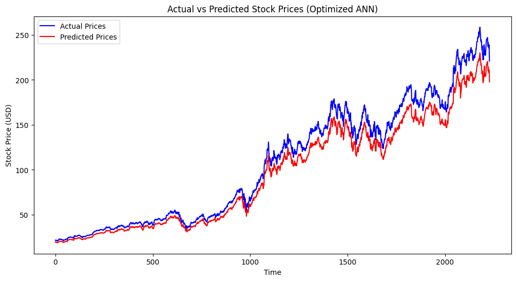

```python
y_pred_opt_scaled = model_optimized_ann.predict(X_test_scaled)

y_pred_opt = scaler_y.inverse_transform(y_pred_opt_scaled)
y_actual_opt = scaler_y.inverse_transform(y_test_scaled)

plt.figure(figsize=(12,6))
plt.plot(y_actual_opt, label="Actual Prices", color='blue')
plt.plot(y_pred_opt, label="Predicted Prices", color='red')
plt.title("Actual vs Predicted Stock Prices (Optimized ANN)")
plt.xlabel("Time")
plt.ylabel("Stock Price (USD)")
plt.legend()
plt.show()
```

The fine-tuning of the deep ANN resulted in significant improvements in both the Mean Absolute Error (MAE) and Mean Squared Error (MSE), leading to a more accurate prediction model. After adjusting the number of layers, neurons per layer, dropout rate, and learning rate, the model not only reduced the error metrics but also produced predicted stock prices that closely follow the actual price trends.

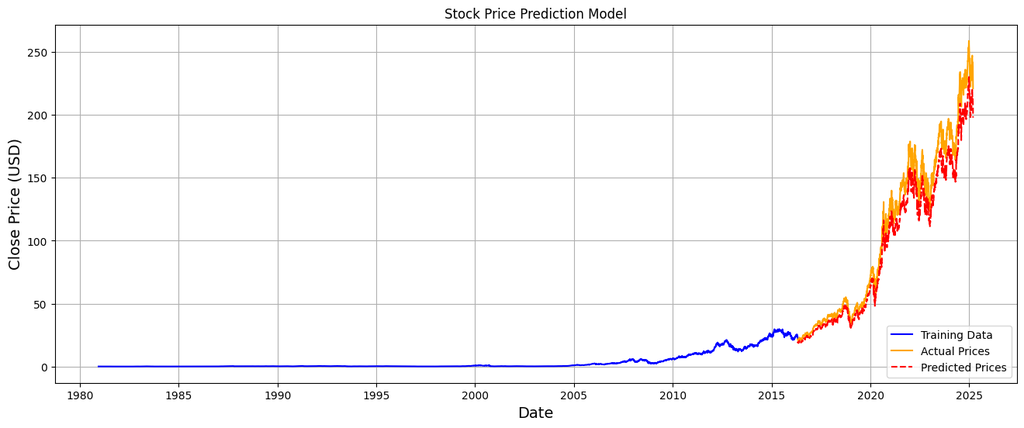

```python
plt.figure(figsize=(16,6))
plt.title('Stock Price Prediction Model')
plt.xlabel('Date', fontsize=14)
plt.ylabel('Close Price (USD)', fontsize=14)

plt.plot(X_train.index, y_train, label='Training Data', color='blue')

plt.plot(X_test.index, y_test, label='Actual Prices', color='orange')

plt.plot(X_test.index, y_pred_opt, label='Predicted Prices', color='red', linestyle='dashed')

plt.legend(loc='lower right')
plt.grid(True)
plt.show()
```

By analyzing the full Apple stock price graph, we can see that the optimized deep ANN aligns much better with the actual prices compared to the initial version. The predictions capture fluctuations more accurately, reducing large deviations and making the model more reliable for forecasting. This confirms that careful hyperparameter tuning plays a crucial role in improving model performance.

### 🔷 LSTM (Recurrent Neural Network)

We are going to continue with LSTM (Long Short-Term Memory), which is a type of neural network designed to learn from past data and recognize patterns over time. LSTMs are a type of Recurrent Neural Network (RNN). Unlike regular models that treat each input separately, LSTMs can remember past stock prices and use them to predict future trends. This makes them perfect for stock market data, where past prices influence future movements. We are choosing LSTM because it helps the model understand how stock prices change over time, making our predictions more accurate.

#### 🧹 Preprocessing

Since LSTMs learn from past data to predict the future, we need to format our dataset into sequences of stock prices. Instead of predicting the next price using only the previous day, we use the last 30 days to make each prediction. The function takes the stock price data and splits it into overlapping sequences, where each input X contains 30 consecutive days of prices, and the target y is the price on the next day. The 30-day window was chosen as a logical balance for this problem. Initially, it was tried to use 1 day, but the predictions were far from good, which required to take measures into this preprocessing step and to think on how much past data is needed for the model to predict the next day. Choosing, a bigger window, for example 60 days, could introduce unnecessary noise. For this exercise, the 30-day window was optimal.

```python
def create_sequences(data, target, time_steps=30):
    X, y = [], []
    for i in range(len(data) - time_steps):
        X.append(data[i:i+time_steps])
        y.append(target[i+time_steps])
    return np.array(X), np.array(y)

time_steps = 30  # last 30 days to predict next day
X_train_lstm, y_train_lstm = create_sequences(X_train_scaled, y_train_scaled, time_steps)
X_test_lstm, y_test_lstm = create_sequences(X_test_scaled, y_test_scaled, time_steps)

print(f"New LSTM Training Shape: {X_train_lstm.shape}, {y_train_lstm.shape}")
print(f"New LSTM Test Shape: {X_test_lstm.shape}, {y_test_lstm.shape}")
```

[output not shown]

#### 🧬 Modelling

Now, we continue with the building of the model. It consists of 2 LSTM layers that process time-series informatin, followed by a dense output layer that predicts the next day's stock price.

```python
model3 = keras.Sequential([
    layers.LSTM(64, return_sequences=True, input_shape=(1, X_train_scaled.shape[1])),
    layers.LSTM(32),
    layers.Dense(1)
])

model3.compile(optimizer='adam', loss='mse', metrics=['mae'])

model3.summary()
```

```
Model: "sequential_2"
```

```
┏━━━━━━━━━━━━━━━━━━━━━━━━━━━━━━━━━┳━━━━━━━━━━━━━━━━━━━━━━━━┳━━━━━━━━━━━━━━━┓
┃ Layer (type)                    ┃ Output Shape           ┃       Param # ┃
┡━━━━━━━━━━━━━━━━━━━━━━━━━━━━━━━━━╇━━━━━━━━━━━━━━━━━━━━━━━━╇━━━━━━━━━━━━━━━┩
│ lstm_7 (LSTM)                   │ (None, 1, 64)          │        17,664 │
├─────────────────────────────────┼────────────────────────┼───────────────┤
│ lstm_8 (LSTM)                   │ (None, 32)             │        12,416 │
├─────────────────────────────────┼────────────────────────┼───────────────┤
│ dense_2 (Dense)                 │ (None, 1)              │            33 │
└─────────────────────────────────┴────────────────────────┴───────────────┘
```

```
 Total params: 30,113 (117.63 KB)
```

```
 Trainable params: 30,113 (117.63 KB)
```

```
 Non-trainable params: 0 (0.00 B)
```

```python
history3 = model3.fit(X_train_lstm, y_train_lstm, epochs=50, batch_size=32, validation_split=0.2, verbose=1)
```

```
222/222 ━━━━━━━━━━━━━━━━━━━━ 7s 23ms/step - loss: 1.7590e-04 - mae: 0.0061 - val_loss: 0.0027 - val_mae: 0.0352
222/222 ━━━━━━━━━━━━━━━━━━━━ 5s 24ms/step - loss: 9.0067e-06 - mae: 0.0017 - val_loss: 0.0084 - val_mae: 0.0727
222/222 ━━━━━━━━━━━━━━━━━━━━ 5s 22ms/step - loss: 6.8792e-06 - mae: 0.0013 - val_loss: 0.0029 - val_mae: 0.0378
222/222 ━━━━━━━━━━━━━━━━━━━━ 4s 20ms/step - loss: 7.4881e-06 - mae: 0.0018 - val_loss: 0.0040 - val_mae: 0.0468
222/222 ━━━━━━━━━━━━━━━━━━━━ 14s 62ms/step - loss: 6.0022e-06 - mae: 0.0013 - val_loss: 0.0031 - val_mae: 0.0402
222/222 ━━━━━━━━━━━━━━━━━━━━ 5s 22ms/step - loss: 6.2331e-06 - mae: 0.0015 - val_loss: 0.0041 - val_mae: 0.0486
222/222 ━━━━━━━━━━━━━━━━━━━━ 5s 22ms/step - loss: 5.6395e-06 - mae: 0.0014 - val_loss: 0.0023 - val_mae: 0.0336
222/222 ━━━━━━━━━━━━━━━━━━━━ 5s 23ms/step - loss: 4.4064e-06 - mae: 0.0012 - val_loss: 0.0033 - val_mae: 0.0414
222/222 ━━━━━━━━━━━━━━━━━━━━ 5s 22ms/step - loss: 5.8251e-06 - mae: 0.0015 - val_loss: 0.0022 - val_mae: 0.0326
222/222 ━━━━━━━━━━━━━━━━━━━━ 5s 21ms/step - loss: 5.7801e-06 - mae: 0.0016 - val_loss: 0.0018 - val_mae: 0.0291
222/222 ━━━━━━━━━━━━━━━━━━━━ 4s 18ms/step - loss: 3.9020e-06 - mae: 0.0012 - val_loss: 0.0023 - val_mae: 0.0331
222/222 ━━━━━━━━━━━━━━━━━━━━ 5s 21ms/step - loss: 5.1575e-06 - mae: 0.0014 - val_loss: 0.0033 - val_mae: 0.0414
222/222 ━━━━━━━━━━━━━━━━━━━━ 4s 20ms/step - loss: 4.0621e-06 - mae: 0.0011 - val_loss: 0.0014 - val_mae: 0.0253
222/222 ━━━━━━━━━━━━━━━━━━━━ 6s 25ms/step - loss: 4.4355e-06 - mae: 0.0012 - val_loss: 0.0018 - val_mae: 0.0290
222/222 ━━━━━━━━━━━━━━━━━━━━ 5s 21ms/step - loss: 3.8143e-06 - mae: 0.0011 - val_loss: 9.8686e-04 - val_mae: 0.0214
222/222 ━━━━━━━━━━━━━━━━━━━━ 5s 22ms/step - loss: 3.4305e-06 - mae: 0.0010 - val_loss: 0.0048 - val_mae: 0.0532
222/222 ━━━━━━━━━━━━━━━━━━━━ 5s 22ms/step - loss: 4.0672e-06 - mae: 0.0011 - val_loss: 0.0033 - val_mae: 0.0413
222/222 ━━━━━━━━━━━━━━━━━━━━ 4s 20ms/step - loss: 3.7784e-06 - mae: 0.0011 - val_loss: 0.0063 - val_mae: 0.0626
222/222 ━━━━━━━━━━━━━━━━━━━━ 5s 22ms/step - loss: 4.3968e-06 - mae: 0.0012 - val_loss: 0.0014 - val_mae: 0.0250
222/222 ━━━━━━━━━━━━━━━━━━━━ 13s 58ms/step - loss: 3.9712e-06 - mae: 0.0012 - val_loss: 0.0043 - val_mae: 0.0483
222/222 ━━━━━━━━━━━━━━━━━━━━ 23s 67ms/step - loss: 3.1966e-06 - mae: 0.0010 - val_loss: 0.0022 - val_mae: 0.0319
222/222 ━━━━━━━━━━━━━━━━━━━━ 9s 41ms/step - loss: 3.1051e-06 - mae: 9.4069e-04 - val_loss: 0.0021 - val_mae: 0.0315
222/222 ━━━━━━━━━━━━━━━━━━━━ 6s 28ms/step - loss: 3.3821e-06 - mae: 0.0010 - val_loss: 0.0025 - val_mae: 0.0346
222/222 ━━━━━━━━━━━━━━━━━━━━ 6s 25ms/step - loss: 2.9163e-06 - mae: 9.4964e-04 - val_loss: 0.0029 - val_mae: 0.0378
222/222 ━━━━━━━━━━━━━━━━━━━━ 5s 20ms/step - loss: 3.2959e-06 - mae: 0.0011 - val_loss: 0.0030 - val_mae: 0.0403
222/222 ━━━━━━━━━━━━━━━━━━━━ 5s 21ms/step - loss: 2.9536e-06 - mae: 0.0011 - val_loss: 0.0012 - val_mae: 0.0232
222/222 ━━━━━━━━━━━━━━━━━━━━ 5s 23ms/step - loss: 4.5315e-06 - mae: 0.0013 - val_loss: 0.0022 - val_mae: 0.0329
222/222 ━━━━━━━━━━━━━━━━━━━━ 5s 24ms/step - loss: 2.7084e-06 - mae: 9.5423e-04 - val_loss: 0.0020 - val_mae: 0.0304
222/222 ━━━━━━━━━━━━━━━━━━━━ 4s 19ms/step - loss: 3.3527e-06 - mae: 0.0011 - val_loss: 0.0016 - val_mae: 0.0268
222/222 ━━━━━━━━━━━━━━━━━━━━ 4s 19ms/step - loss: 2.7928e-06 - mae: 9.7524e-04 - val_loss: 0.0020 - val_mae: 0.0301
222/222 ━━━━━━━━━━━━━━━━━━━━ 5s 22ms/step - loss: 2.7659e-06 - mae: 9.5430e-04 - val_loss: 0.0022 - val_mae: 0.0323
222/222 ━━━━━━━━━━━━━━━━━━━━ 5s 23ms/step - loss: 3.1876e-06 - mae: 0.0010 - val_loss: 0.0045 - val_mae: 0.0517
222/222 ━━━━━━━━━━━━━━━━━━━━ 5s 23ms/step - loss: 3.0429e-06 - mae: 9.8822e-04 - val_loss: 0.0031 - val_mae: 0.0407
222/222 ━━━━━━━━━━━━━━━━━━━━ 5s 22ms/step - loss: 3.0480e-06 - mae: 9.7501e-04 - val_loss: 0.0024 - val_mae: 0.0348
222/222 ━━━━━━━━━━━━━━━━━━━━ 5s 23ms/step - loss: 2.7618e-06 - mae: 9.5746e-04 - val_loss: 0.0033 - val_mae: 0.0426
222/222 ━━━━━━━━━━━━━━━━━━━━ 5s 22ms/step - loss: 2.5671e-06 - mae: 9.6923e-04 - val_loss: 0.0028 - val_mae: 0.0377
222/222 ━━━━━━━━━━━━━━━━━━━━ 5s 23ms/step - loss: 2.7640e-06 - mae: 9.7851e-04 - val_loss: 0.0022 - val_mae: 0.0321
222/222 ━━━━━━━━━━━━━━━━━━━━ 4s 20ms/step - loss: 2.5712e-06 - mae: 9.1875e-04 - val_loss: 0.0013 - val_mae: 0.0238
222/222 ━━━━━━━━━━━━━━━━━━━━ 4s 19ms/step - loss: 3.2791e-06 - mae: 0.0010 - val_loss: 0.0027 - val_mae: 0.0367
222/222 ━━━━━━━━━━━━━━━━━━━━ 5s 21ms/step - loss: 2.8777e-06 - mae: 9.9823e-04 - val_loss: 0.0037 - val_mae: 0.0455
222/222 ━━━━━━━━━━━━━━━━━━━━ 4s 19ms/step - loss: 2.9710e-06 - mae: 9.5459e-04 - val_loss: 0.0028 - val_mae: 0.0384
222/222 ━━━━━━━━━━━━━━━━━━━━ 4s 19ms/step - loss: 2.8513e-06 - mae: 9.7225e-04 - val_loss: 0.0020 - val_mae: 0.0305
222/222 ━━━━━━━━━━━━━━━━━━━━ 4s 18ms/step - loss: 3.4339e-06 - mae: 0.0012 - val_loss: 0.0017 - val_mae: 0.0276
222/222 ━━━━━━━━━━━━━━━━━━━━ 4s 19ms/step - loss: 2.8244e-06 - mae: 9.9057e-04 - val_loss: 0.0020 - val_mae: 0.0304
222/222 ━━━━━━━━━━━━━━━━━━━━ 4s 20ms/step - loss: 2.4782e-06 - mae: 9.4483e-04 - val_loss: 0.0025 - val_mae: 0.0356
222/222 ━━━━━━━━━━━━━━━━━━━━ 5s 21ms/step - loss: 2.7397e-06 - mae: 0.0010 - val_loss: 0.0018 - val_mae: 0.0285
222/222 ━━━━━━━━━━━━━━━━━━━━ 8s 37ms/step - loss: 2.2024e-06 - mae: 8.1692e-04 - val_loss: 0.0025 - val_mae: 0.0364
222/222 ━━━━━━━━━━━━━━━━━━━━ 18s 72ms/step - loss: 2.9187e-06 - mae: 0.0011 - val_loss: 0.0023 - val_mae: 0.0336
222/222 ━━━━━━━━━━━━━━━━━━━━ 15s 68ms/step - loss: 2.4764e-06 - mae: 8.4327e-04 - val_loss: 0.0021 - val_mae: 0.0322
222/222 ━━━━━━━━━━━━━━━━━━━━ 12s 30ms/step - loss: 2.6752e-06 - mae: 8.8051e-04 - val_loss: 0.0025 - val_mae: 0.0359
```

#### 🧐 Evaluation

```python
test_loss3, test_mae3 = model3.evaluate(X_test_lstm, y_test_lstm)

print(f"Test MAE: {test_mae3}")
print(f"Test MSE: {test_loss3}")
```

```
68/68 ━━━━━━━━━━━━━━━━━━━━ 0s 7ms/step - loss: 1.3948 - mae: 0.6711
Test MAE: 1.8031166791915894
Test MSE: 5.816145896911621
```

```
68/68 ━━━━━━━━━━━━━━━━━━━━ 1s 7ms/step
```

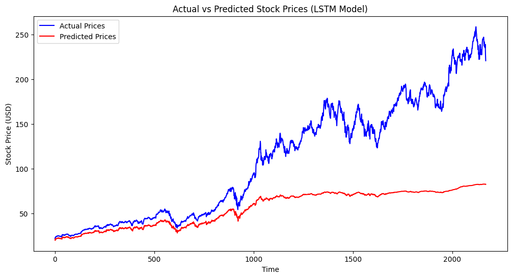

```python
y_pred3_scaled = model3.predict(X_test_lstm)

y_pred3 = scaler_y.inverse_transform(y_pred3_scaled.reshape(-1, 1))
y_actual3 = scaler_y.inverse_transform(y_test_lstm.reshape(-1, 1))

plt.figure(figsize=(12,6))
plt.plot(y_actual3, label="Actual Prices", color='blue')
plt.plot(y_pred3, label="Predicted Prices", color='red')
plt.title("Actual vs Predicted Stock Prices (LSTM Model)")
plt.xlabel("Time")
plt.ylabel("Stock Price (USD)")
plt.legend()
plt.show()
```

The LSTM without any hypertuning is giving a good MAE with a lot room for improvement. The plot of the predicted/real prices shows that the model's predicted prices start similarly to the real prices, showing that the model learns short-term trends good. However, as time progresses, the predicted prices start to diverge a lot more from the actual prices. This happens because LSTMs learn patterns based on historical data, but they struggle with long-term forecasting due to several factors:

- Market Volatility: LSTMs rely on historical trends, but stock prices are affected by unexpected events (e.g., news, economic shifts) that the model cannot predict.
- Limited Context Window: The model is trained on 30-day sequences, so it may struggle to capture long-term dependencies beyond that period.

To improve long-term accuracy, we are going to explore Bidirectional LSTMs.

#### Hyperparameter Tuning for LSTM

The next function defines an LSTM model with tunable hyperparameters, allowing Keras Tuner to find the best architecture for stock price prediction. This tuning process ensures that the LSTM model is optimized for learning stock price patterns while minimizing overfitting and improving predictive accuracy. The function is similar to the one for the Feedforward ANN.

```python
def build_lstm_model(hp):
    model = keras.Sequential()

    model.add(layers.LSTM(
        hp.Int("units_1", min_value=32, max_value=256, step=32),
        return_sequences=True,
        input_shape=(X_train_lstm.shape[1], X_train_lstm.shape[2])
    ))

    for i in range(hp.Int("num_layers", 1, 6)):
        model.add(layers.LSTM(hp.Int(f"units_{i+2}", min_value=32, max_value=256, step=32), return_sequences=(i != 2)))

    model.add(layers.Dropout(hp.Choice("dropout", [0.1, 0.2, 0.3])))

    model.add(layers.Dense(1))

    model.compile(
        optimizer=Adam(hp.Choice("learning_rate", [0.0001, 0.001, 0.01])),
        loss="mse",
        metrics=["mae"]
    )

    return model
```

```python
tuner_lstm = kt.RandomSearch(
    build_lstm_model,
    objective="val_mae",
    max_trials=10,
    executions_per_trial=2,
    directory="hyperparameter_tuning",
    project_name="lstm_tuning"
)

tuner_lstm.search(X_train_lstm, y_train_lstm, epochs=50, validation_split=0.2, batch_size=32, verbose=1)
```

```
Trial 10 Complete [00h 19m 36s]
val_mae: 0.03136037103831768

Best val_mae So Far: 0.021210906095802784
Total elapsed time: 02h 57m 13s
```

LSTM models usually take longer time to run. The tuning process with the function above took a long time, but it provided some insights on the best parameters.

```python
best_hps_lstm = tuner_lstm.get_best_hyperparameters(num_trials=1)[0]

print(f"Best number of layers: {best_hps_lstm.get('num_layers')}")
print(f"Best units for first layer: {best_hps_lstm.get('units_1')}")
print(f"Best dropout rate: {best_hps_lstm.get('dropout')}")
print(f"Best learning rate: {best_hps_lstm.get('learning_rate')}")
```

```
Best number of layers: 3
Best units for first layer: 32
Best dropout rate: 0.3
Best learning rate: 0.001
```

```python
model_optimized_lstm = keras.Sequential([
    layers.LSTM(32, return_sequences=True, input_shape=(X_train_lstm.shape[1], X_train_lstm.shape[2])),
    layers.Dropout(0.3),

    layers.LSTM(64, return_sequences=True),
    layers.Dropout(0.3),

    layers.LSTM(32),
    layers.Dropout(0.3),

    layers.Dense(1)
])

model_optimized_lstm.compile(optimizer=Adam(learning_rate=0.001), loss='mse', metrics=['mae'])

model_optimized_lstm.summary()
```

```
Model: "sequential_1"
```

```
┏━━━━━━━━━━━━━━━━━━━━━━━━━━━━━━━━━┳━━━━━━━━━━━━━━━━━━━━━━━━┳━━━━━━━━━━━━━━━┓
┃ Layer (type)                    ┃ Output Shape           ┃       Param # ┃
┡━━━━━━━━━━━━━━━━━━━━━━━━━━━━━━━━━╇━━━━━━━━━━━━━━━━━━━━━━━━╇━━━━━━━━━━━━━━━┩
│ lstm_4 (LSTM)                   │ (None, 30, 32)         │         4,736 │
├─────────────────────────────────┼────────────────────────┼───────────────┤
│ dropout_1 (Dropout)             │ (None, 30, 32)         │             0 │
├─────────────────────────────────┼────────────────────────┼───────────────┤
│ lstm_5 (LSTM)                   │ (None, 30, 64)         │        24,832 │
├─────────────────────────────────┼────────────────────────┼───────────────┤
│ dropout_2 (Dropout)             │ (None, 30, 64)         │             0 │
├─────────────────────────────────┼────────────────────────┼───────────────┤
│ lstm_6 (LSTM)                   │ (None, 32)             │        12,416 │
├─────────────────────────────────┼────────────────────────┼───────────────┤
│ dropout_3 (Dropout)             │ (None, 32)             │             0 │
├─────────────────────────────────┼────────────────────────┼───────────────┤
│ dense_1 (Dense)                 │ (None, 1)              │            33 │
└─────────────────────────────────┴────────────────────────┴───────────────┘
```

```
 Total params: 42,017 (164.13 KB)
```

```
 Trainable params: 42,017 (164.13 KB)
```

```
 Non-trainable params: 0 (0.00 B)
```

```python
history_optimized_lstm = model_optimized_lstm.fit(X_train_lstm, y_train_lstm, epochs=50, batch_size=32, validation_split=0.2, verbose=1)
```

[output not shown]

```python
test_loss_optimized_lstm, test_mae_optimized_lstm = model_optimized_lstm.evaluate(X_test_lstm, y_test_lstm)

print(f"Test MAE: {test_mae_optimized_lstm}")
print(f"Test MSE: {test_loss_optimized_lstm}")
```

```
68/68 ━━━━━━━━━━━━━━━━━━━━ 1s 13ms/step - loss: 5.2451 - mae: 1.6766
Test MAE: 3.4027578830718994
Test MSE: 16.717453002929688
```

Initially, the LSTM model was not performing as well as the Deep ANN, but it still managed to capture short-term stock price trends reasonably well. However, its overall accuracy was lower than that of the Deep ANN, as it struggled with long-term price fluctuations and had a tendency to smooth out predictions rather than precisely following the actual price movements. After fine-tuning, the LSTM model’s performance significantly worsened, leading to even higher MAE and MSE values. There are several possible reasons for this decline:

- Over-regularization with High Dropout – The tuned LSTM had a dropout rate of 0.3, applied after every layer. While dropout prevents overfitting, too much dropout can remove too much useful information.
- Reduced Number of Units in the First Layer – The original LSTM had 64 units in the first layer, while the fine-tuned version started with only 32 units. This reduced the model’s capacity to capture important features early on, potentially weakening its ability to recognize key trends.

These factors combined likely made the fine-tuned LSTM too constrained, preventing it from effectively learning stock price relationships. Unlike the deep ANN, which benefited from tuning, the LSTM architecture was better before that, resulting in relatively good short-term trends.

### 🔷 Bidirectional LSTM

The last model, we are going to try for this problem, is the Bidirectional LSTM (BiLSTM). It is an extension of the standard LSTM, but processes the data in both forward and backward directions. This can be beneficial for stock price predictions, as market trends are often influenced by both recent movements and longer-term patterns.

#### 🧬 Modelling

```python
model4 = keras.Sequential([
    Bidirectional(layers.LSTM(128, return_sequences=True), input_shape=(30, X_train_scaled.shape[1])),
    Bidirectional(layers.LSTM(64)),
    layers.Dense(1)
])

model4.compile(optimizer='adam', loss='mse', metrics=['mae'])

model4.summary()
```

```
Model: "sequential_6"
```

```
┏━━━━━━━━━━━━━━━━━━━━━━━━━━━━━━━━━┳━━━━━━━━━━━━━━━━━━━━━━━━┳━━━━━━━━━━━━━━━┓
┃ Layer (type)                    ┃ Output Shape           ┃       Param # ┃
┡━━━━━━━━━━━━━━━━━━━━━━━━━━━━━━━━━╇━━━━━━━━━━━━━━━━━━━━━━━━╇━━━━━━━━━━━━━━━┩
│ bidirectional_5 (Bidirectional) │ (None, 30, 256)        │       136,192 │
├─────────────────────────────────┼────────────────────────┼───────────────┤
│ bidirectional_6 (Bidirectional) │ (None, 128)            │       164,352 │
├─────────────────────────────────┼────────────────────────┼───────────────┤
│ dense_11 (Dense)                │ (None, 1)              │           129 │
└─────────────────────────────────┴────────────────────────┴───────────────┘
```

```
 Total params: 300,673 (1.15 MB)
```

```
 Trainable params: 300,673 (1.15 MB)
```

```
 Non-trainable params: 0 (0.00 B)
```

```python
history4 = model4.fit(X_train_lstm, y_train_lstm, epochs=50, batch_size=32, validation_split=0.2, verbose=1)
```

```
222/222 ━━━━━━━━━━━━━━━━━━━━ 13s 45ms/step - loss: 1.7902e-04 - mae: 0.0072 - val_loss: 6.9767e-04 - val_mae: 0.0185
222/222 ━━━━━━━━━━━━━━━━━━━━ 9s 41ms/step - loss: 6.9571e-06 - mae: 0.0016 - val_loss: 0.0029 - val_mae: 0.0428
222/222 ━━━━━━━━━━━━━━━━━━━━ 9s 40ms/step - loss: 7.6411e-06 - mae: 0.0016 - val_loss: 4.5296e-04 - val_mae: 0.0148
222/222 ━━━━━━━━━━━━━━━━━━━━ 9s 39ms/step - loss: 7.2356e-06 - mae: 0.0016 - val_loss: 6.9564e-04 - val_mae: 0.0190
222/222 ━━━━━━━━━━━━━━━━━━━━ 9s 40ms/step - loss: 5.5082e-06 - mae: 0.0015 - val_loss: 0.0023 - val_mae: 0.0397
222/222 ━━━━━━━━━━━━━━━━━━━━ 9s 42ms/step - loss: 4.6561e-06 - mae: 0.0012 - val_loss: 2.0955e-04 - val_mae: 0.0109
222/222 ━━━━━━━━━━━━━━━━━━━━ 11s 47ms/step - loss: 6.3020e-06 - mae: 0.0016 - val_loss: 0.0011 - val_mae: 0.0256
222/222 ━━━━━━━━━━━━━━━━━━━━ 11s 49ms/step - loss: 4.2554e-06 - mae: 0.0013 - val_loss: 2.9412e-04 - val_mae: 0.0123
222/222 ━━━━━━━━━━━━━━━━━━━━ 10s 46ms/step - loss: 4.9195e-06 - mae: 0.0013 - val_loss: 6.1258e-04 - val_mae: 0.0179
222/222 ━━━━━━━━━━━━━━━━━━━━ 10s 45ms/step - loss: 5.5121e-06 - mae: 0.0014 - val_loss: 2.2399e-04 - val_mae: 0.0107
222/222 ━━━━━━━━━━━━━━━━━━━━ 11s 51ms/step - loss: 4.4586e-06 - mae: 0.0012 - val_loss: 0.0010 - val_mae: 0.0250
222/222 ━━━━━━━━━━━━━━━━━━━━ 10s 44ms/step - loss: 4.9086e-06 - mae: 0.0014 - val_loss: 1.8509e-04 - val_mae: 0.0102
222/222 ━━━━━━━━━━━━━━━━━━━━ 9s 42ms/step - loss: 3.1973e-06 - mae: 0.0011 - val_loss: 0.0011 - val_mae: 0.0276
222/222 ━━━━━━━━━━━━━━━━━━━━ 11s 48ms/step - loss: 5.2106e-06 - mae: 0.0015 - val_loss: 1.5415e-04 - val_mae: 0.0091
222/222 ━━━━━━━━━━━━━━━━━━━━ 10s 46ms/step - loss: 3.8905e-06 - mae: 0.0011 - val_loss: 2.0007e-04 - val_mae: 0.0101
222/222 ━━━━━━━━━━━━━━━━━━━━ 11s 49ms/step - loss: 4.8787e-06 - mae: 0.0013 - val_loss: 8.3901e-04 - val_mae: 0.0230
222/222 ━━━━━━━━━━━━━━━━━━━━ 11s 49ms/step - loss: 3.8897e-06 - mae: 0.0012 - val_loss: 3.9705e-04 - val_mae: 0.0145
222/222 ━━━━━━━━━━━━━━━━━━━━ 11s 48ms/step - loss: 3.5115e-06 - mae: 0.0011 - val_loss: 1.4692e-04 - val_mae: 0.0089
222/222 ━━━━━━━━━━━━━━━━━━━━ 11s 51ms/step - loss: 4.8756e-06 - mae: 0.0014 - val_loss: 2.1886e-04 - val_mae: 0.0116
222/222 ━━━━━━━━━━━━━━━━━━━━ 10s 46ms/step - loss: 4.0188e-06 - mae: 0.0011 - val_loss: 1.5872e-04 - val_mae: 0.0095
222/222 ━━━━━━━━━━━━━━━━━━━━ 10s 43ms/step - loss: 3.6915e-06 - mae: 0.0011 - val_loss: 2.9461e-04 - val_mae: 0.0122
222/222 ━━━━━━━━━━━━━━━━━━━━ 13s 58ms/step - loss: 2.8188e-06 - mae: 9.1634e-04 - val_loss: 5.1798e-04 - val_mae: 0.0168
222/222 ━━━━━━━━━━━━━━━━━━━━ 10s 47ms/step - loss: 4.2036e-06 - mae: 0.0013 - val_loss: 3.9806e-04 - val_mae: 0.0143
222/222 ━━━━━━━━━━━━━━━━━━━━ 11s 50ms/step - loss: 3.5634e-06 - mae: 0.0011 - val_loss: 1.5537e-04 - val_mae: 0.0091
222/222 ━━━━━━━━━━━━━━━━━━━━ 11s 51ms/step - loss: 3.2534e-06 - mae: 0.0011 - val_loss: 4.7668e-04 - val_mae: 0.0159
222/222 ━━━━━━━━━━━━━━━━━━━━ 24s 107ms/step - loss: 2.5797e-06 - mae: 9.2931e-04 - val_loss: 9.7298e-04 - val_mae: 0.0244
222/222 ━━━━━━━━━━━━━━━━━━━━ 31s 63ms/step - loss: 3.0166e-06 - mae: 9.8631e-04 - val_loss: 3.9852e-04 - val_mae: 0.0144
222/222 ━━━━━━━━━━━━━━━━━━━━ 17s 77ms/step - loss: 2.8868e-06 - mae: 0.0010 - val_loss: 5.6242e-04 - val_mae: 0.0178
222/222 ━━━━━━━━━━━━━━━━━━━━ 14s 62ms/step - loss: 2.6964e-06 - mae: 9.3403e-04 - val_loss: 3.9875e-04 - val_mae: 0.0142
222/222 ━━━━━━━━━━━━━━━━━━━━ 25s 114ms/step - loss: 2.4615e-06 - mae: 8.8267e-04 - val_loss: 1.5152e-04 - val_mae: 0.0093
222/222 ━━━━━━━━━━━━━━━━━━━━ 25s 113ms/step - loss: 2.8928e-06 - mae: 9.7040e-04 - val_loss: 2.9222e-04 - val_mae: 0.0117
222/222 ━━━━━━━━━━━━━━━━━━━━ 11s 50ms/step - loss: 3.0309e-06 - mae: 0.0010 - val_loss: 2.8414e-04 - val_mae: 0.0115
222/222 ━━━━━━━━━━━━━━━━━━━━ 11s 48ms/step - loss: 2.5326e-06 - mae: 8.9109e-04 - val_loss: 7.0446e-04 - val_mae: 0.0201
222/222 ━━━━━━━━━━━━━━━━━━━━ 11s 52ms/step - loss: 2.8565e-06 - mae: 9.7733e-04 - val_loss: 7.8959e-04 - val_mae: 0.0214
222/222 ━━━━━━━━━━━━━━━━━━━━ 15s 68ms/step - loss: 3.0890e-06 - mae: 0.0011 - val_loss: 4.7157e-04 - val_mae: 0.0156
222/222 ━━━━━━━━━━━━━━━━━━━━ 14s 61ms/step - loss: 2.7807e-06 - mae: 8.6046e-04 - val_loss: 2.4508e-04 - val_mae: 0.0107
222/222 ━━━━━━━━━━━━━━━━━━━━ 8s 38ms/step - loss: 3.5779e-06 - mae: 0.0012 - val_loss: 1.6874e-04 - val_mae: 0.0095
222/222 ━━━━━━━━━━━━━━━━━━━━ 10s 44ms/step - loss: 3.1075e-06 - mae: 0.0010 - val_loss: 6.2607e-04 - val_mae: 0.0179
222/222 ━━━━━━━━━━━━━━━━━━━━ 11s 50ms/step - loss: 2.8928e-06 - mae: 0.0010 - val_loss: 8.4351e-04 - val_mae: 0.0216
222/222 ━━━━━━━━━━━━━━━━━━━━ 11s 50ms/step - loss: 3.1169e-06 - mae: 0.0010 - val_loss: 3.7539e-04 - val_mae: 0.0130
222/222 ━━━━━━━━━━━━━━━━━━━━ 11s 48ms/step - loss: 3.0709e-06 - mae: 0.0010 - val_loss: 0.0011 - val_mae: 0.0252
222/222 ━━━━━━━━━━━━━━━━━━━━ 9s 42ms/step - loss: 2.8301e-06 - mae: 9.3410e-04 - val_loss: 5.9920e-04 - val_mae: 0.0171
222/222 ━━━━━━━━━━━━━━━━━━━━ 9s 41ms/step - loss: 2.2975e-06 - mae: 8.3292e-04 - val_loss: 0.0015 - val_mae: 0.0298
222/222 ━━━━━━━━━━━━━━━━━━━━ 9s 41ms/step - loss: 2.7214e-06 - mae: 9.0501e-04 - val_loss: 2.1696e-04 - val_mae: 0.0120
222/222 ━━━━━━━━━━━━━━━━━━━━ 9s 41ms/step - loss: 3.6359e-06 - mae: 0.0011 - val_loss: 8.3224e-04 - val_mae: 0.0203
222/222 ━━━━━━━━━━━━━━━━━━━━ 9s 42ms/step - loss: 2.2838e-06 - mae: 8.2256e-04 - val_loss: 0.0014 - val_mae: 0.0280
222/222 ━━━━━━━━━━━━━━━━━━━━ 9s 43ms/step - loss: 2.5669e-06 - mae: 9.1978e-04 - val_loss: 0.0013 - val_mae: 0.0277
222/222 ━━━━━━━━━━━━━━━━━━━━ 9s 43ms/step - loss: 3.1166e-06 - mae: 0.0011 - val_loss: 5.7514e-04 - val_mae: 0.0158
222/222 ━━━━━━━━━━━━━━━━━━━━ 10s 46ms/step - loss: 2.6647e-06 - mae: 9.5261e-04 - val_loss: 9.4215e-04 - val_mae: 0.0213
222/222 ━━━━━━━━━━━━━━━━━━━━ 10s 46ms/step - loss: 2.6679e-06 - mae: 9.0246e-04 - val_loss: 0.0014 - val_mae: 0.0274
```

#### 🧐 Evaluation

```python
test_loss4, test_mae4 = model4.evaluate(X_test_lstm, y_test_lstm)

print(f"Test MAE: {test_mae4}")
print(f"Test MSE: {test_loss4}")
```

```
68/68 ━━━━━━━━━━━━━━━━━━━━ 1s 19ms/step - loss: 1.3603 - mae: 0.6493
Test MAE: 1.7723051309585571
Test MSE: 5.631588459014893
```

```
68/68 ━━━━━━━━━━━━━━━━━━━━ 2s 18ms/step
```

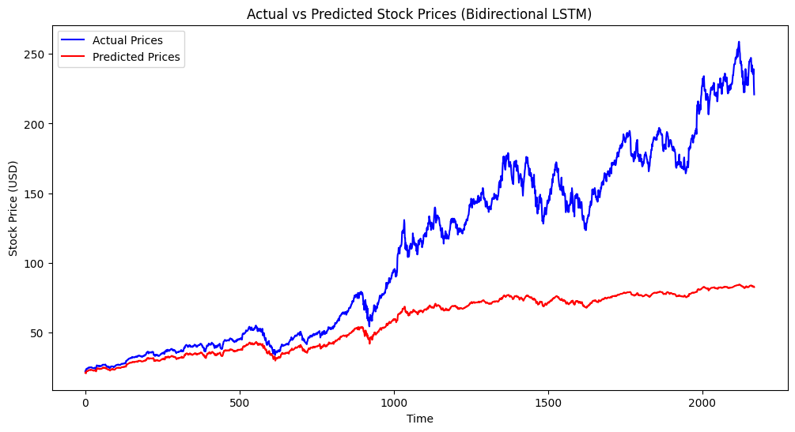

```python
y_pred_bilstm_scaled = model4.predict(X_test_lstm)

y_pred_bilstm = scaler_y.inverse_transform(y_pred_bilstm_scaled.reshape(-1, 1))
y_actual_bilstm = scaler_y.inverse_transform(y_test_lstm.reshape(-1, 1))

plt.figure(figsize=(12,6))
plt.plot(y_actual_bilstm, label="Actual Prices", color='blue')
plt.plot(y_pred_bilstm, label="Predicted Prices", color='red')
plt.title("Actual vs Predicted Stock Prices (Bidirectional LSTM)")
plt.xlabel("Time")
plt.ylabel("Stock Price (USD)")
plt.legend()
plt.show()
```

The bidirectional LSTM has similar results as the normal LSTM, predicting relatively good in the short-term period and flattening out in the long-term.

### Comparison

As you can see below, all models' predictions are plotted. We have the whole Apple stock data with the predicted values of the 4 models.

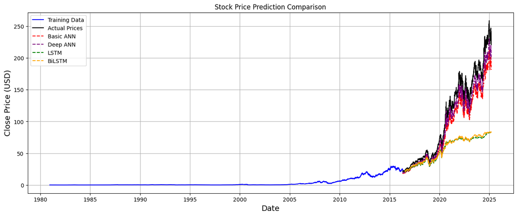

```python
plt.figure(figsize=(16,6))
plt.title('Stock Price Prediction Comparison')
plt.xlabel('Date', fontsize=14)
plt.ylabel('Close Price (USD)', fontsize=14)

plt.plot(y_train.index, y_train, label='Training Data', color='blue')

plt.plot(y_test.index, y_test, label='Actual Prices', color='black')

# Basic ANN
plt.plot(y_test.index, y_pred, label='Basic ANN', color='red', linestyle='dashed')

# Deep ANN (finetuned)
plt.plot(y_test.index, y_pred_opt, label='Deep ANN', color='purple', linestyle='dashed')

# LSTM (we need to remove the first 30 days to make the x and y the same length, same for BiLSTM)
plt.plot(y_test.index[-len(y_pred3):], y_pred3, label='LSTM', color='green', linestyle='dashed')

# BiLSTM
plt.plot(y_test.index[-len(y_pred_bilstm):], y_pred_bilstm, label='BiLSTM', color='orange', linestyle='dashed')


plt.legend(loc='upper left')
plt.grid(True)
plt.show()
```

After evaluating all four models, the deep ANN emerged as the most effective for predicting stock prices, especially after fine-tuning. It achieved the lowest Mean Absolute Error (MAE) and Mean Squared Error (MSE) while closely following the actual price trends. The Basic ANN also performed well in recognizing the trend, though not as accurately as the fine-tuned Deep ANN. Meanwhile, both LSTM models (regular and BiLSTM) underperformed, struggling to capture long-term price movements effectively.

Possible reasons why the Feeforward ANN models performed better than the LSTMs:

- Stock Prices Are Not Purely Sequential – While LSTMs are designed for time-series forecasting, stock prices are influenced by many external factors beyond just historical prices. A feedforward ANN, which treats data as independent features rather than sequences, can better capture complex non-linear relationships without being overly dependent on past time steps.
- LSTMs Need More Data to Shine – LSTMs generally work best with large datasets where long-term dependencies are important. However, in this case, a smaller dataset and shorter sequences limited the LSTM’s advantage, making a simpler ANN more effective.
- Stock Price Movements Are Short-Term Focused – The Deep ANN’s strength lies in its ability to recognize patterns in numerical relationships, whereas LSTMs rely on long-term dependencies. Since stock prices often follow short-term trends and momentum shifts, a feedforward ANN is more suitable for pattern recognition rather than sequential memory retention.

## 🤝 Conclusion

This notebook was a comprehensive exploration of Artificial Neural Networks (ANNs) and their application in stock price prediction. Throughout this project, I gained valuable insights into both the technical aspects of building machine learning models with ANNs and the financial domain of stock price movements. The process of data provisioning, preprocessing, model selection, hyperparameter tuning, and evaluation provided a deep understanding of how different neural network architectures perform in time-series forecasting. Data was collected from Yahoo Finance and thoroughly explored. I experimented with different models, tuned their hyperparameters and tried different combinations. I focused on basic ANN and deep ANN, as well as LSTMs. Each model was trained and evaluated using appropriate metrics and plotting the results. One of the biggest takeaways of this project was seeing which types of ANNs work best for this problem, comparing the models and gathering the best results. Stock price prediction is inherently difficult and uncertain due to market volatility, external factors, and investor sentiment, which models cannot fully capture. While deep learning can identify patterns and short-term trends, it cannot predict sudden market shifts caused by news or economic events. This project was a valuable learning experience in both Artificial Neural Networks and stock market analysis. By going through the entire AI methodology, from domain understanding and data provisioning to modelling and evaluation, I developed a deeper understanding of model selection, hyperparameter tuning, and the challenges of financial forecasting. While predicting stock prices remains a complex and uncertain task, this project provided practical insights into deep learning for time-series forecasting and helped reinforce the importance of model optimization and experimentation.

## 📚 References

1. Investopedia. (2024). Efficient market hypothesis (EMH): Definition and Critique. Retrieved March 11, 2025, from https://www.investopedia.com/terms/e/efficientmarkethypothesis.asp
2. Mercer. (2024). Mercer Investments' AI integration in investment management 2024 global manager survey. Retrieved March 11, 2025, from https://www.mercer.com/insights/investments/portfolio-strategies/ai-in-investment-management-survey/